# Open Case Studies: Exploring global patterns of obesity across rural and urban regions

### **Removing unnecessary repeated header information**

So, let’s remove all the header information and the page number lines from the `rural_urban` object, then we will make a single line header for the beginning. One way to do this is to find all lines that include either “Women” or “Men” and only keep this data.

First, let’s see how many lines include “Women” or “Men”. We can do this by first identifying the lines that contain these patterns and then check the length of the resulting vector for the line numbers that contain these patterns. Note, the `"|"` indicates that we are looking for either “Women” or “Men”.

```r
#scroll through the output!
stringr::str_which(string = rural_urban,
                   pattern = "Women|Men")
```

```
  [1]   5   6   7   8   9  10  11  12  13  14  15  16  17  18  19  20  21  22
 [19]  23  24  25  26  27  28  29  30  31  32  33  34  35  36  37  38  39  40
 [37]  41  42  43  44  45  46  47  48  55  56  57  58  59  60  61  62  63  64
 [55]  65  66  67  68  69  70  71  72  73  74  75  76  77  78  79  80  81  82
 [73]  83  84  85  86  87  88  89  90  91  92  93  94  95  96  97  98 105 106
 [91] 107 108 109 110 111 112 113 114 115 116 117 118 119 120 121 122 123 124
[109] 125 126 127 128 129 130 131 132 133 134 135 136 137 138 139 140 141 142
[127] 143 144 145 146 147 148 155 156 157 158 159 160 161 162 163 164 165 166
[145] 167 168 169 170 171 172 173 174 175 176 177 178 179 180 181 182 183 184
[163] 185 186 187 188 189 190 191 192 193 194 195 196 197 198 205 206 207 208
[181] 209 210 211 212 213 214 215 216 217 218 219 220 221 222 223 224 225 226
[199] 227 228 229 230 231 232 233 234 235 236 237 238 239 240 241 242 243 244
[217] 245 246 247 248 255 256 257 258 259 260 261 262 263 264 265 266 267 268
[235] 269 270 271 272 273 274 275 276 277 278 279 280 281 282 283 284 285 286
[253] 287 288 289 290 291 292 293 294 295 296 297 298 305 306 307 308 309 310
[271] 311 312 313 314 315 316 317 318 319 320 321 322 323 324 325 326 327 328
[289] 329 330 331 332 333 334 335 336 337 338 339 340 341 342 343 344 345 346
[307] 347 348 355 356 357 358 359 360 361 362 363 364 365 366 367 368 369 370
[325] 371 372 373 374 375 376 377 378 379 380 381 382 383 384 385 386 387 388
[343] 389 390 391 392 393 394 395 396 397 398 405 406 407 408 409 410 411 412
[361] 413 414 415 416 417 418 419 420 421 422 423 424 425 426 427 428 429 430
[379] 431 432 433 434 435 436 437 438 439 440 441 442 443 444 445 446 447 448
[397] 455 456 457 458
```

```r
length(stringr::str_which(string = rural_urban,
                          pattern = "Women|Men"))
```

```
[1] 400
```

Note that `str_which()` is case sensitive, so it would not work to use “women” as the pattern, and using “men” would return the lines that contain “Wo**men**” or “Ye**men**” etc. Try this out with `pattern = "women"` and `pattern = "men"` to see the result!

```r
rural_urban <- str_subset(string = rural_urban,
                          pattern = "Women|Men")
```

We can check our data now using either `head()` from base R or `glimpse()` from the `tibble` and `dplyr` package. (Yup, the same function is available from both packages!) The `head()` function shows us the first rows or lines of the data, while the `glimpse()` function provides us information about the total size of the object and shows us the first line or row.

```r
dplyr::glimpse(rural_urban)
```

```
 chr [1:400] "Men 20.2 (17.8-22.7) 19.7 (17.2-22.2) 22.4 (20.0-25.0) 22.8 (20.3-25.3) 22.5 (20.0-25.0) 23.6 (21.0-26.1)" ...
```

```r
head(rural_urban)
```

```
[1] "Men 20.2 (17.8-22.7) 19.7 (17.2-22.2) 22.4 (20.0-25.0) 22.8 (20.3-25.3) 22.5 (20.0-25.0) 23.6 (21.0-26.1)"
[2] "Afghanistan Women 20.6 (18.4-22.8) 20.1 (17.8-22.4) 23.2 (20.9-25.4) 24.4 (23.3-25.4) 23.6 (22.5-24.8) 26.3 (25.1-27.4)"
[3] "Men 25.2 (23.9-26.5) 25.0 (23.7-26.4) 25.4 (24.0-26.7) 27.0 (26.0-27.9) 26.9 (25.9-27.9) 27.0 (26.0-28.0)"
[4] "Albania Women 26.0 (24.1-27.9) 26.1 (24.1-28.1) 25.9 (23.9-27.8) 26.0 (24.8-27.2) 26.2 (24.8-27.5) 25.9 (24.6-27.2)"
[5] "Men 22.1 (20.8-23.3) 21.8 (20.5-23.1) 22.3 (21.0-23.6) 25.1 (24.5-25.7) 24.8 (24.1-25.4) 25.2 (24.6-25.9)"
[6] "Algeria Women 24.0 (22.2-25.7) 23.3 (21.4-25.1) 24.8 (22.9-26.6) 27.4 (26.7-28.0) 27.0 (26.3-27.8) 27.5 (26.7-28.2)"
```

Great! So now our data looks much better but we need to add back our header and we would like this to only be a single line to make it easy to transform our data into a table or table-like object.

As a reminder, here is what our header used to look like:

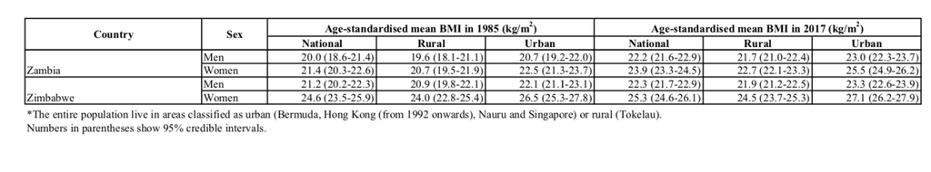

We will add a new header after first dealing with some additional spacing and missing data issues.

### **Dealing with spacing**

First let’s try splitting our header-less data into columns based on spaces using the `str_split()` function, where we specify that we are splitting the data based on the pattern of a space (the space is included in quotes). Referring to [str_split() documentation](https://www.rdocumentation.org/packages/stringr/versions/1.4.0/topics/str_split), the `simplify` argument is set to `FALSE` by default, where a list of character vectors is returned. If it is set to `TRUE` as we will be doing here, a character matrix is returned.

Here, we will take a look at just the first 10 lines using the `[1:10,]` syntax:

```r
#scroll through the output!
str_split(string = rural_urban,
          pattern = " ",
          simplify = TRUE)[1:10,]
```

```
      [,1]          [,2]    [,3]          [,4]          [,5]
 [1,] "Men"         "20.2"  "(17.8-22.7)" "19.7"        "(17.2-22.2)"
 [2,] "Afghanistan" "Women" "20.6"        "(18.4-22.8)" "20.1"
 [3,] "Men"         "25.2"  "(23.9-26.5)" "25.0"        "(23.7-26.4)"
 [4,] "Albania"     "Women" "26.0"        "(24.1-27.9)" "26.1"
 [5,] "Men"         "22.1"  "(20.8-23.3)" "21.8"        "(20.5-23.1)"
 [6,] "Algeria"     "Women" "24.0"        "(22.2-25.7)" "23.3"
 [7,] "Men"         "33.7"  "(32.7-34.7)" "32.6"        "(31.7-33.5)"
 [8,] "American"    "Samoa" "Women"       "34.3"        "(33.1-35.6)"
 [9,] "Men"         "25.0"  "(22.5-27.4)" "25.3"        "(22.8-27.7)"
[10,] "Andorra"     "Women" "25.2"        "(22.0-28.4)" "25.4"
      [,6]          [,7]          [,8]          [,9]          [,10]
 [1,] "22.4"        "(20.0-25.0)" "22.8"        "(20.3-25.3)" "22.5"
 [2,] "(17.8-22.4)" "23.2"        "(20.9-25.4)" "24.4"        "(23.3-25.4)"
 [3,] "25.4"        "(24.0-26.7)" "27.0"        "(26.0-27.9)" "26.9"
```

[output cut: 29 more lines]

This almost worked, but unfortunately country names that have spaces will be a problem. For example, we can see that “American Samoa” has been divided into two columns and all subsequent columns are shifted.

Let’s try this another way.

As we can see by looking at our `rural_urban` data, the country information is only present when the sex is Women. Let’s try to extract the country information from the rows that contain data about Women.

```r
head(rural_urban)
```

```
[1] "Men 20.2 (17.8-22.7) 19.7 (17.2-22.2) 22.4 (20.0-25.0) 22.8 (20.3-25.3) 22.5 (20.0-25.0) 23.6 (21.0-26.1)"
[2] "Afghanistan Women 20.6 (18.4-22.8) 20.1 (17.8-22.4) 23.2 (20.9-25.4) 24.4 (23.3-25.4) 23.6 (22.5-24.8) 26.3 (25.1-27.4)"
[3] "Men 25.2 (23.9-26.5) 25.0 (23.7-26.4) 25.4 (24.0-26.7) 27.0 (26.0-27.9) 26.9 (25.9-27.9) 27.0 (26.0-28.0)"
[4] "Albania Women 26.0 (24.1-27.9) 26.1 (24.1-28.1) 25.9 (23.9-27.8) 26.0 (24.8-27.2) 26.2 (24.8-27.5) 25.9 (24.6-27.2)"
[5] "Men 22.1 (20.8-23.3) 21.8 (20.5-23.1) 22.3 (21.0-23.6) 25.1 (24.5-25.7) 24.8 (24.1-25.4) 25.2 (24.6-25.9)"
[6] "Algeria Women 24.0 (22.2-25.7) 23.3 (21.4-25.1) 24.8 (22.9-26.6) 27.4 (26.7-28.0) 27.0 (26.3-27.8) 27.5 (26.7-28.2)"
```

To do this, we start by noticing that the sex always starts with either a capital “W” if the sex is female. Note, we need to use a space before the “W” otherwise we will split some of the country names if the names starts with “W”.

Here, we will also introduce the concept of piping, which uses `%>%` from the `tidyverse` to pipe the output from one function to the input for another function. This is really useful when we have multiple steps, which we will show soon.

First, we will select just the data for Women and Men separately:

```r
Women <- str_subset(string = rural_urban,
                    pattern = "Women")
Men <- str_subset(string = rural_urban,
                    pattern = "Men")


head(Women)
```

```
[1] "Afghanistan Women 20.6 (18.4-22.8) 20.1 (17.8-22.4) 23.2 (20.9-25.4) 24.4 (23.3-25.4) 23.6 (22.5-24.8) 26.3 (25.1-27.4)"
[2] "Albania Women 26.0 (24.1-27.9) 26.1 (24.1-28.1) 25.9 (23.9-27.8) 26.0 (24.8-27.2) 26.2 (24.8-27.5) 25.9 (24.6-27.2)"
[3] "Algeria Women 24.0 (22.2-25.7) 23.3 (21.4-25.1) 24.8 (22.9-26.6) 27.4 (26.7-28.0) 27.0 (26.3-27.8) 27.5 (26.7-28.2)"
[4] "American Samoa Women 34.3 (33.1-35.6) 34.1 (33.0-35.2) 34.4 (33.0-35.8) 35.3 (33.7-36.9) 35.0 (33.1-36.9) 35.4 (33.7-37.1)"
[5] "Andorra Women 25.2 (22.0-28.4) 25.4 (22.2-28.7) 25.2 (22.0-28.4) 25.3 (22.1-28.6) 25.2 (21.9-28.5) 25.3 (22.1-28.6)"
[6] "Angola Women 21.3 (18.0-24.6) 20.9 (17.6-24.3) 22.7 (19.3-26.0) 24.4 (21.2-27.7) 23.3 (20.0-26.7) 25.7 (22.4-29.1)"
```

```r
head(Men)
```

```
[1] "Men 20.2 (17.8-22.7) 19.7 (17.2-22.2) 22.4 (20.0-25.0) 22.8 (20.3-25.3) 22.5 (20.0-25.0) 23.6 (21.0-26.1)"
[2] "Men 25.2 (23.9-26.5) 25.0 (23.7-26.4) 25.4 (24.0-26.7) 27.0 (26.0-27.9) 26.9 (25.9-27.9) 27.0 (26.0-28.0)"
[3] "Men 22.1 (20.8-23.3) 21.8 (20.5-23.1) 22.3 (21.0-23.6) 25.1 (24.5-25.7) 24.8 (24.1-25.4) 25.2 (24.6-25.9)"
[4] "Men 33.7 (32.7-34.7) 32.6 (31.7-33.5) 34.0 (32.9-35.1) 34.3 (33.0-35.6) 34.6 (33.1-35.9) 34.2 (32.9-35.6)"
[5] "Men 25.0 (22.5-27.4) 25.3 (22.8-27.7) 25.0 (22.5-27.4) 26.8 (24.4-29.2) 26.8 (24.3-29.2) 26.8 (24.3-29.3)"
[6] "Men 20.5 (17.9-23.1) 20.2 (17.6-22.9) 21.4 (18.8-24.0) 22.6 (20.0-25.1) 22.0 (19.4-24.6) 23.2 (20.6-25.9)"
```

And then split the `Women` data based on the pattern `pattern = " Women"` (Note that the space before the word “Women” is included - so that it is not within the country data). Here we take our `Women` dataset and pipe it into the first argument of the `str_split()` function, where then we can split on the pattern `" Women"`. We then pipe through the `unlist()` function so that the results are a vector instead of a list. We assign this new result to the `country_split` object.

```r
country_split <-
  Women %>%
  stringr::str_split(pattern = " Women") %>%
  unlist()

head(country_split)
```

```
[1] "Afghanistan"
[2] " 20.6 (18.4-22.8) 20.1 (17.8-22.4) 23.2 (20.9-25.4) 24.4 (23.3-25.4) 23.6 (22.5-24.8) 26.3 (25.1-27.4)"
[3] "Albania"
[4] " 26.0 (24.1-27.9) 26.1 (24.1-28.1) 25.9 (23.9-27.8) 26.0 (24.8-27.2) 26.2 (24.8-27.5) 25.9 (24.6-27.2)"
[5] "Algeria"
[6] " 24.0 (22.2-25.7) 23.3 (21.4-25.1) 24.8 (22.9-26.6) 27.4 (26.7-28.0) 27.0 (26.3-27.8) 27.5 (26.7-28.2)"
```

However, we can also do the same thing in a single step, where we replace the `Women` dataset with the code we used to create that dataset. So first, we select the “Women” and then we split the data by ” Women” to create a new dataset all within the same chunk of code.

```r
country_split <-
  str_subset(string = rural_urban,
             pattern = "Women") %>%
  stringr::str_split(pattern= " Women") %>%
  unlist()

head(country_split)
```

```
[1] "Afghanistan"
[2] " 20.6 (18.4-22.8) 20.1 (17.8-22.4) 23.2 (20.9-25.4) 24.4 (23.3-25.4) 23.6 (22.5-24.8) 26.3 (25.1-27.4)"
[3] "Albania"
[4] " 26.0 (24.1-27.9) 26.1 (24.1-28.1) 25.9 (23.9-27.8) 26.0 (24.8-27.2) 26.2 (24.8-27.5) 25.9 (24.6-27.2)"
[5] "Algeria"
[6] " 24.0 (22.2-25.7) 23.3 (21.4-25.1) 24.8 (22.9-26.6) 27.4 (26.7-28.0) 27.0 (26.3-27.8) 27.5 (26.7-28.2)"
```

Now, we can see that `Country` is always the odd rows and the BMI data for Women is the even rows. We can select the odd rows using the **Modulus (Remainder from division) operator**. This operator looks like this `%%`. All odd values such as 3, 7, or 15 when divided by 2 would leave a remainder of 1. We will select just these rows using the `filter()` function of `dplyr`.

```r
country <-
  tibble(country_split) %>%
  dplyr::filter(row_number() %% 2 == 1)
```

We can take a look to make sure that all the country names look as expected. You can scroll through the country names if you hover over the data.

```r
country
```

```
                       country_split
1                        Afghanistan
2                            Albania
3                            Algeria
4                     American Samoa
5                            Andorra
6                             Angola
7                Antigua and Barbuda
8                          Argentina
9                            Armenia
10                         Australia
11                           Austria
12                        Azerbaijan
13                           Bahamas
14                           Bahrain
```

[output cut: 186 more lines]

Looks good! We have 200 countries represented in our dataset.

Great! Now we have a list of the countries that can be used for both the male and female data.

Remember the even rows are the rows with the BMI data for women. These row values have a remainder of 0 when divided by 2. Let’s select that data too.

```r
Women_BMI <-
  tibble(country_split) %>%
  dplyr::filter(row_number() %% 2 == 0)

head(Women_BMI)
```

```
# A tibble: 6 × 1
  country_split
  <chr>
1 " 20.6 (18.4-22.8) 20.1 (17.8-22.4) 23.2 (20.9-25.4) 24.4 (23.3-25.4) 23.6 (2…
2 " 26.0 (24.1-27.9) 26.1 (24.1-28.1) 25.9 (23.9-27.8) 26.0 (24.8-27.2) 26.2 (2…
3 " 24.0 (22.2-25.7) 23.3 (21.4-25.1) 24.8 (22.9-26.6) 27.4 (26.7-28.0) 27.0 (2…
4 " 34.3 (33.1-35.6) 34.1 (33.0-35.2) 34.4 (33.0-35.8) 35.3 (33.7-36.9) 35.0 (3…
5 " 25.2 (22.0-28.4) 25.4 (22.2-28.7) 25.2 (22.0-28.4) 25.3 (22.1-28.6) 25.2 (2…
6 " 21.3 (18.0-24.6) 20.9 (17.6-24.3) 22.7 (19.3-26.0) 24.4 (21.2-27.7) 23.3 (2…
```

This looks similar to our `Men` data (although slightly different):

```r
head(Men)
```

```
[1] "Men 20.2 (17.8-22.7) 19.7 (17.2-22.2) 22.4 (20.0-25.0) 22.8 (20.3-25.3) 22.5 (20.0-25.0) 23.6 (21.0-26.1)"
[2] "Men 25.2 (23.9-26.5) 25.0 (23.7-26.4) 25.4 (24.0-26.7) 27.0 (26.0-27.9) 26.9 (25.9-27.9) 27.0 (26.0-28.0)"
[3] "Men 22.1 (20.8-23.3) 21.8 (20.5-23.1) 22.3 (21.0-23.6) 25.1 (24.5-25.7) 24.8 (24.1-25.4) 25.2 (24.6-25.9)"
[4] "Men 33.7 (32.7-34.7) 32.6 (31.7-33.5) 34.0 (32.9-35.1) 34.3 (33.0-35.6) 34.6 (33.1-35.9) 34.2 (32.9-35.6)"
[5] "Men 25.0 (22.5-27.4) 25.3 (22.8-27.7) 25.0 (22.5-27.4) 26.8 (24.4-29.2) 26.8 (24.3-29.2) 26.8 (24.3-29.3)"
[6] "Men 20.5 (17.9-23.1) 20.2 (17.6-22.9) 21.4 (18.8-24.0) 22.6 (20.0-25.1) 22.0 (19.4-24.6) 23.2 (20.6-25.9)"
```

Notice how the data in each row is in quotes. This is because these are character strings. We can check this by using the base `class()` function.

```r
class(Men)
```

```
[1] "character"
```

Whereas the `Women_BMI` data is a tibble.

```r
class(Women_BMI)
```

```
[1] "tbl_df"     "tbl"        "data.frame"
```

Let’s make the `Men` data into a tibble as well:

```r
Men <- tibble(Men)
```

It’s always a good idea to check that your data objects are the size you expect when wrangling. We can do so with the `dim()` function, which shows us the dimensions of data objects.

```r
dim(Women_BMI)
```

```
[1] 200   1
```

```r
dim(Men)
```

```
[1] 200   1
```

```r
head(Women_BMI)
```

```
# A tibble: 6 × 1
  country_split
  <chr>
1 " 20.6 (18.4-22.8) 20.1 (17.8-22.4) 23.2 (20.9-25.4) 24.4 (23.3-25.4) 23.6 (2…
2 " 26.0 (24.1-27.9) 26.1 (24.1-28.1) 25.9 (23.9-27.8) 26.0 (24.8-27.2) 26.2 (2…
3 " 24.0 (22.2-25.7) 23.3 (21.4-25.1) 24.8 (22.9-26.6) 27.4 (26.7-28.0) 27.0 (2…
4 " 34.3 (33.1-35.6) 34.1 (33.0-35.2) 34.4 (33.0-35.8) 35.3 (33.7-36.9) 35.0 (3…
5 " 25.2 (22.0-28.4) 25.4 (22.2-28.7) 25.2 (22.0-28.4) 25.3 (22.1-28.6) 25.2 (2…
6 " 21.3 (18.0-24.6) 20.9 (17.6-24.3) 22.7 (19.3-26.0) 24.4 (21.2-27.7) 23.3 (2…
```

```r
head(Men)
```

```
# A tibble: 6 × 1
  Men
  <chr>
1 Men 20.2 (17.8-22.7) 19.7 (17.2-22.2) 22.4 (20.0-25.0) 22.8 (20.3-25.3) 22.5 …
2 Men 25.2 (23.9-26.5) 25.0 (23.7-26.4) 25.4 (24.0-26.7) 27.0 (26.0-27.9) 26.9 …
3 Men 22.1 (20.8-23.3) 21.8 (20.5-23.1) 22.3 (21.0-23.6) 25.1 (24.5-25.7) 24.8 …
4 Men 33.7 (32.7-34.7) 32.6 (31.7-33.5) 34.0 (32.9-35.1) 34.3 (33.0-35.6) 34.6 …
5 Men 25.0 (22.5-27.4) 25.3 (22.8-27.7) 25.0 (22.5-27.4) 26.8 (24.4-29.2) 26.8 …
6 Men 20.5 (17.9-23.1) 20.2 (17.6-22.9) 21.4 (18.8-24.0) 22.6 (20.0-25.1) 22.0 …
```

Great! There are 200 rows of character strings with the BMI data like we expected to match the 200 countries in our data.

We do however need to add the word `" Women"` back to the `Women_BMI` data. To do this we will use the `glue()` function of the `glue` package.

Here is a simple example of how this function glues two things together.

```r
where <-"the moon"

glue::glue("the cow jumped over {where}")
```

```
the cow jumped over the moon
```

Now let’s add the word “Women” to each row of the `Women_BMI` data using `glue`.

First let’s pull the `country_split` data out as a vector to make this simpler when we `glue`. To do this we will use the `pull()` function of the `dplyr` package. This function will allow us to extract or pull out the single variable called `country_split` which contains the BMI values for women from within the tibble called `Women_BMI` which we just created by grabbing only the even rows of our original `country_split` tibble.

Then, let’s use the `first()` function of the `dplyr` package to get a reminder of what just the first row of the `country_split` column of the `Women_BMI` data looks like.

```r
women_data <- Women_BMI %>%
  pull(country_split)

dplyr::first(women_data)
```

```
[1] " 20.6 (18.4-22.8) 20.1 (17.8-22.4) 23.2 (20.9-25.4) 24.4 (23.3-25.4) 23.6 (22.5-24.8) 26.3 (25.1-27.4)"
```

Now we will paste the word `"Women"` in the beginning of each value in the vector using the `glue()` function.

Note that there will be a space in between. This is because the space is already in front of the first BMI value.

```r
Women <- glue("Women{women_data}")
head(Women)
```

```
Women 20.6 (18.4-22.8) 20.1 (17.8-22.4) 23.2 (20.9-25.4) 24.4 (23.3-25.4) 23.6 (22.5-24.8) 26.3 (25.1-27.4)
Women 26.0 (24.1-27.9) 26.1 (24.1-28.1) 25.9 (23.9-27.8) 26.0 (24.8-27.2) 26.2 (24.8-27.5) 25.9 (24.6-27.2)
Women 24.0 (22.2-25.7) 23.3 (21.4-25.1) 24.8 (22.9-26.6) 27.4 (26.7-28.0) 27.0 (26.3-27.8) 27.5 (26.7-28.2)
Women 34.3 (33.1-35.6) 34.1 (33.0-35.2) 34.4 (33.0-35.8) 35.3 (33.7-36.9) 35.0 (33.1-36.9) 35.4 (33.7-37.1)
Women 25.2 (22.0-28.4) 25.4 (22.2-28.7) 25.2 (22.0-28.4) 25.3 (22.1-28.6) 25.2 (21.9-28.5) 25.3 (22.1-28.6)
Women 21.3 (18.0-24.6) 20.9 (17.6-24.3) 22.7 (19.3-26.0) 24.4 (21.2-27.7) 23.3 (20.0-26.7) 25.7 (22.4-29.1)
```

You could also do all of this in one step but its less obvious what is happening.

Here we can pull the `country_split` data out of the `Women_BMI` object and then paste `"Women"` in front of each string in one command.

```r
Women <- glue("Women{pull(Women_BMI,country_split)}")
```

If we try splitting our data by space again, will it have the expected number of columns? What about the rows that contain `na*` values?

```r
unknown <-
  Men%>%
  filter(str_detect(pattern ="na\\*",
                    string = Men))

head(unknown)
```

```
# A tibble: 5 × 1
  Men
  <chr>
1 Men 24.3 (21.8-26.8) na* 24.3 (21.8-26.8) 26.7 (24.3-29.2) na* 26.7 (24.3-29.…
2 Men 22.4 (21.4-23.3) 21.5 (20.2-22.8) 22.4 (21.5-23.4) 24.8 (23.6-26.1) na* 2…
3 Men 32.6 (32.0-33.2) na* 32.6 (32.0-33.2) 32.9 (31.7-34.1) na* 32.9 (31.7-34.…
4 Men 22.8 (22.2-23.3) na* 22.8 (22.2-23.3) 24.4 (23.6-25.1) na* 24.4 (23.6-25.…
5 Men 29.6 (28.1-31.1) 29.6 (28.1-31.1) na* 32.3 (31.4-33.2) 32.3 (31.4-33.2) n…
```

Now we can try splitting by a space

```r
tibble::as_tibble(str_split(pull(unknown, Men), " ",
                            simplify = TRUE))
```

```
# A tibble: 5 × 12
  V1    V2    V3          V4    V5     V6    V7    V8    V9    V10   V11   V12
  <chr> <chr> <chr>       <chr> <chr>  <chr> <chr> <chr> <chr> <chr> <chr> <chr>
1 Men   24.3  (21.8-26.8) na*   24.3   (21.… 26.7  (24.… na*   26.7  (24.… ""
2 Men   22.4  (21.4-23.3) 21.5  (20.2… 22.4  (21.… 24.8  (23.… na*   24.8  "(23…
3 Men   32.6  (32.0-33.2) na*   32.6   (32.… 32.9  (31.… na*   32.9  (31.… ""
4 Men   22.8  (22.2-23.3) na*   22.8   (22.… 24.4  (23.… na*   24.4  (23.… ""
5 Men   29.6  (28.1-31.1) 29.6  (28.1… na*   32.3  (31.… 32.3  (31.… na*   ""
```

So close! Notice that the `"na*"` values have shifted the subsequent values within the columns because typically there is a space between the BMI and the credible intervals. Here we can see this data in our original pdf:

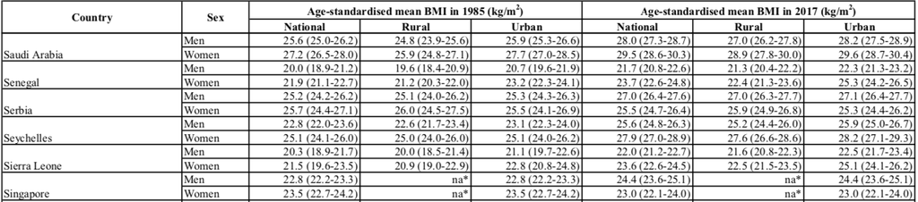

### **Dealing with NA values**

We need to replace our `na*` values with something that includes a space so that when we separate our data by space, we will have two values instead of one when we have an `na*`. Therefore, `na* na*` should work.

So, in order to use the functions within the `stringr` package, our `Men` data needs to be of `character` class, so let’s check that now.

```r
head(Men)
```

```
# A tibble: 6 × 1
  Men
  <chr>
1 Men 20.2 (17.8-22.7) 19.7 (17.2-22.2) 22.4 (20.0-25.0) 22.8 (20.3-25.3) 22.5 …
2 Men 25.2 (23.9-26.5) 25.0 (23.7-26.4) 25.4 (24.0-26.7) 27.0 (26.0-27.9) 26.9 …
3 Men 22.1 (20.8-23.3) 21.8 (20.5-23.1) 22.3 (21.0-23.6) 25.1 (24.5-25.7) 24.8 …
4 Men 33.7 (32.7-34.7) 32.6 (31.7-33.5) 34.0 (32.9-35.1) 34.3 (33.0-35.6) 34.6 …
5 Men 25.0 (22.5-27.4) 25.3 (22.8-27.7) 25.0 (22.5-27.4) 26.8 (24.4-29.2) 26.8 …
6 Men 20.5 (17.9-23.1) 20.2 (17.6-22.9) 21.4 (18.8-24.0) 22.6 (20.0-25.1) 22.0 …
```

The `<chr>` indicates that our `Men` data is already `character`. But if this is not the case, we could use the `as.character()` function that allows us to change factor data within to the character class.

We are also changing the structure so that the data is not within a column called `Men`.

```r
Men <- pull(Men, Men)
head(Men)
```

```
[1] "Men 20.2 (17.8-22.7) 19.7 (17.2-22.2) 22.4 (20.0-25.0) 22.8 (20.3-25.3) 22.5 (20.0-25.0) 23.6 (21.0-26.1)"
[2] "Men 25.2 (23.9-26.5) 25.0 (23.7-26.4) 25.4 (24.0-26.7) 27.0 (26.0-27.9) 26.9 (25.9-27.9) 27.0 (26.0-28.0)"
[3] "Men 22.1 (20.8-23.3) 21.8 (20.5-23.1) 22.3 (21.0-23.6) 25.1 (24.5-25.7) 24.8 (24.1-25.4) 25.2 (24.6-25.9)"
[4] "Men 33.7 (32.7-34.7) 32.6 (31.7-33.5) 34.0 (32.9-35.1) 34.3 (33.0-35.6) 34.6 (33.1-35.9) 34.2 (32.9-35.6)"
[5] "Men 25.0 (22.5-27.4) 25.3 (22.8-27.7) 25.0 (22.5-27.4) 26.8 (24.4-29.2) 26.8 (24.3-29.2) 26.8 (24.3-29.3)"
[6] "Men 20.5 (17.9-23.1) 20.2 (17.6-22.9) 21.4 (18.8-24.0) 22.6 (20.0-25.1) 22.0 (19.4-24.6) 23.2 (20.6-25.9)"
```

```r
Men <-
  stringr::str_replace_all(string = Men,
                           pattern = "na\\*",
                           replacement = "na\\* na\\*")

# The \\ are necessary because the * is a special character
# The * would typically indicate any possible value,
# but here we actually want a "*" instead
# Thus the double backslash does that for us
# Here we are replacing all occurrences of the na* values
#(thus str_replace_all instead of str_replace) with na* na*.
```

Let’s check that it worked…

```r
Men[20:30]
```

```
 [1] "Men 20.7 (19.4-22.1) 20.3 (18.9-21.7) 21.7 (20.3-23.1) 22.7 (22.0-23.3) 22.1 (21.3-22.8) 23.4 (22.7-24.1)"
 [2] "Men 24.3 (21.8-26.8) na* na* 24.3 (21.8-26.8) 26.7 (24.3-29.2) na* na* 26.7 (24.3-29.2)"
 [3] "Men 20.6 (19.1-22.1) 20.3 (18.7-21.8) 23.1 (21.5-24.6) 23.5 (22.8-24.3) 23.1 (22.2-23.9) 24.2 (23.3-25.2)"
 [4] "Men 23.3 (21.0-25.5) 22.9 (20.6-25.2) 23.6 (21.3-25.9) 26.1 (23.9-28.4) 25.3 (23.1-27.5) 26.5 (24.2-28.8)"
 [5] "Men 24.9 (23.5-26.2) 24.8 (23.4-26.2) 25.0 (23.6-26.4) 26.8 (25.7-27.8) 26.7 (25.7-27.8) 26.8 (25.7-27.9)"
 [6] "Men 20.6 (19.2-22.0) 20.3 (18.8-21.7) 21.4 (20.0-22.9) 22.6 (21.9-23.4) 21.9 (20.9-22.8) 23.2 (22.3-24.0)"
 [7] "Men 23.3 (22.5-24.0) 22.2 (21.4-23.0) 23.7 (22.9-24.5) 26.2 (25.7-26.7) 25.0 (24.3-25.6) 26.4 (25.9-26.9)"
 [8] "Men 24.0 (22.5-25.4) 23.7 (22.1-25.1) 24.2 (22.7-25.7) 27.1 (26.4-27.7) 26.6 (26.0-27.3) 27.2 (26.5-27.9)"
 [9] "Men 25.0 (23.8-26.4) 24.9 (23.5-26.4) 25.1 (23.8-26.5) 27.0 (25.8-28.1) 27.0 (25.7-28.3) 27.0 (25.7-28.2)"
[10] "Men 20.2 (18.8-21.5) 20.0 (18.6-21.4) 21.4 (19.9-22.9) 22.2 (21.4-23.0) 21.8 (21.0-22.6) 23.1 (22.1-24.1)"
[11] "Men 20.2 (17.7-22.6) 20.1 (17.6-22.5) 21.2 (18.7-23.6) 22.1 (19.8-24.5) 22.0 (19.6-24.3) 23.2 (20.8-25.6)"
```

Great!

Now for the Women data object

```r
class(Women)
```

```
[1] "glue"      "character"
```

```r
# the female data is already character type
Women <-
  stringr::str_replace_all(string = Women,
                           pattern = "na\\*",
                           replacement = "na\\* na\\*")
Women[20:30]
```

```
 [1] "Women 20.6 (19.1-22.0) 20.1 (18.5-21.6) 21.8 (20.3-23.3) 24.3 (23.5-25.0) 23.2 (22.5-24.0) 25.5 (24.7-26.3)"
 [2] "Women 25.4 (22.2-28.6) na* na* 25.4 (22.2-28.6) 28.5 (25.3-31.6) na* na* 28.5 (25.3-31.6)"
 [3] "Women 20.7 (18.4-22.9) 20.3 (18.0-22.6) 23.0 (20.8-25.3) 24.6 (23.7-25.5) 23.8 (22.7-24.9) 25.9 (24.7-27.0)"
 [4] "Women 23.8 (22.3-25.3) 23.0 (21.4-24.5) 24.6 (23.1-26.1) 27.9 (26.5-29.3) 27.0 (25.6-28.5) 28.3 (26.8-29.7)"
 [5] "Women 25.5 (23.5-27.4) 25.7 (23.7-27.7) 25.1 (23.1-27.0) 25.7 (24.4-27.1) 26.0 (24.6-27.5) 25.3 (23.9-26.8)"
 [6] "Women 24.2 (22.2-26.2) 23.7 (21.5-25.8) 25.6 (23.5-27.7) 26.2 (25.3-27.1) 25.0 (23.8-26.2) 27.0 (26.0-28.2)"
 [7] "Women 24.0 (23.2-25.0) 23.1 (22.1-24.1) 24.4 (23.5-25.4) 26.9 (26.2-27.5) 26.4 (25.7-27.2) 26.9 (26.3-27.6)"
 [8] "Women 23.6 (21.4-25.6) 22.9 (20.7-25.0) 24.0 (21.8-26.1) 27.4 (26.6-28.1) 27.0 (26.1-27.8) 27.5 (26.7-28.2)"
 [9] "Women 25.2 (23.4-27.1) 25.5 (23.4-27.6) 25.0 (23.1-26.9) 25.6 (24.1-27.1) 26.0 (24.2-27.8) 25.5 (23.9-27.1)"
[10] "Women 19.9 (18.7-21.2) 19.6 (18.4-20.9) 22.0 (20.7-23.3) 22.2 (21.4-23.1) 21.1 (20.2-22.0) 24.7 (23.7-25.7)"
[11] "Women 19.6 (17.5-21.7) 19.5 (17.4-21.6) 21.7 (19.5-23.8) 21.1 (20.3-22.0) 20.7 (19.8-21.6) 24.0 (23.0-24.9)"
```

Great, now we can split our data by spaces.

### **Splitting the data**

We will split our data finally by spaces using the `str_split()` function of the `stringr` package. We can check the rows with NA values by looking at rows 20-30.

```r
Men <- tibble::as_tibble(str_split(Men, " ",
                                   simplify = TRUE))
Men[20:30,]
```

```
# A tibble: 11 × 13
   V1    V2    V3    V4    V5    V6    V7    V8    V9    V10   V11   V12   V13
   <chr> <chr> <chr> <chr> <chr> <chr> <chr> <chr> <chr> <chr> <chr> <chr> <chr>
 1 Men   20.7  (19.… 20.3  (18.… 21.7  (20.… 22.7  (22.… 22.1  (21.… 23.4  (22.…
 2 Men   24.3  (21.… na*   na*   24.3  (21.… 26.7  (24.… na*   na*   26.7  (24.…
 3 Men   20.6  (19.… 20.3  (18.… 23.1  (21.… 23.5  (22.… 23.1  (22.… 24.2  (23.…
 4 Men   23.3  (21.… 22.9  (20.… 23.6  (21.… 26.1  (23.… 25.3  (23.… 26.5  (24.…
 5 Men   24.9  (23.… 24.8  (23.… 25.0  (23.… 26.8  (25.… 26.7  (25.… 26.8  (25.…
 6 Men   20.6  (19.… 20.3  (18.… 21.4  (20.… 22.6  (21.… 21.9  (20.… 23.2  (22.…
 7 Men   23.3  (22.… 22.2  (21.… 23.7  (22.… 26.2  (25.… 25.0  (24.… 26.4  (25.…
 8 Men   24.0  (22.… 23.7  (22.… 24.2  (22.… 27.1  (26.… 26.6  (26.… 27.2  (26.…
 9 Men   25.0  (23.… 24.9  (23.… 25.1  (23.… 27.0  (25.… 27.0  (25.… 27.0  (25.…
10 Men   20.2  (18.… 20.0  (18.… 21.4  (19.… 22.2  (21.… 21.8  (21.… 23.1  (22.…
11 Men   20.2  (17.… 20.1  (17.… 21.2  (18.… 22.1  (19.… 22.0  (19.… 23.2  (20.…
```

Great! It looks good!

Now for the `Women` data.

```r
Women <- as_tibble(str_split(Women, " ",
                             simplify = TRUE))
head(Women)
```

```
# A tibble: 6 × 13
  V1    V2    V3     V4    V5    V6    V7    V8    V9    V10   V11   V12   V13
  <chr> <chr> <chr>  <chr> <chr> <chr> <chr> <chr> <chr> <chr> <chr> <chr> <chr>
1 Women 20.6  (18.4… 20.1  (17.… 23.2  (20.… 24.4  (23.… 23.6  (22.… 26.3  (25.…
2 Women 26.0  (24.1… 26.1  (24.… 25.9  (23.… 26.0  (24.… 26.2  (24.… 25.9  (24.…
3 Women 24.0  (22.2… 23.3  (21.… 24.8  (22.… 27.4  (26.… 27.0  (26.… 27.5  (26.…
4 Women 34.3  (33.1… 34.1  (33.… 34.4  (33.… 35.3  (33.… 35.0  (33.… 35.4  (33.…
5 Women 25.2  (22.0… 25.4  (22.… 25.2  (22.… 25.3  (22.… 25.2  (21.… 25.3  (22.…
6 Women 21.3  (18.0… 20.9  (17.… 22.7  (19.… 24.4  (21.… 23.3  (20.… 25.7  (22.…
```

```r
Women[20:30,]
```

```
# A tibble: 11 × 13
   V1    V2    V3    V4    V5    V6    V7    V8    V9    V10   V11   V12   V13
   <chr> <chr> <chr> <chr> <chr> <chr> <chr> <chr> <chr> <chr> <chr> <chr> <chr>
 1 Women 20.6  (19.… 20.1  (18.… 21.8  (20.… 24.3  (23.… 23.2  (22.… 25.5  (24.…
 2 Women 25.4  (22.… na*   na*   25.4  (22.… 28.5  (25.… na*   na*   28.5  (25.…
 3 Women 20.7  (18.… 20.3  (18.… 23.0  (20.… 24.6  (23.… 23.8  (22.… 25.9  (24.…
 4 Women 23.8  (22.… 23.0  (21.… 24.6  (23.… 27.9  (26.… 27.0  (25.… 28.3  (26.…
 5 Women 25.5  (23.… 25.7  (23.… 25.1  (23.… 25.7  (24.… 26.0  (24.… 25.3  (23.…
 6 Women 24.2  (22.… 23.7  (21.… 25.6  (23.… 26.2  (25.… 25.0  (23.… 27.0  (26.…
 7 Women 24.0  (23.… 23.1  (22.… 24.4  (23.… 26.9  (26.… 26.4  (25.… 26.9  (26.…
 8 Women 23.6  (21.… 22.9  (20.… 24.0  (21.… 27.4  (26.… 27.0  (26.… 27.5  (26.…
 9 Women 25.2  (23.… 25.5  (23.… 25.0  (23.… 25.6  (24.… 26.0  (24.… 25.5  (23.…
10 Women 19.9  (18.… 19.6  (18.… 22.0  (20.… 22.2  (21.… 21.1  (20.… 24.7  (23.…
11 Women 19.6  (17.… 19.5  (17.… 21.7  (19.… 21.1  (20.… 20.7  (19.… 24.0  (23.…
```

We can see that our `na` values look correct.

Looks good!

### **Adding new header**

We’ll wait to add `Country` to the header until we add the country information to our data.

```r
new_header <- c("Sex","National_BMI_1985",
                "National_BMI_1985_CI", "Rural_BMI_1985",
                "Rural_BMI_1985_CI", "Urban_BMI_1985",
                "Urban_BMI_1985_CI", "National_BMI_2017",
                "National_BMI_2017_CI","Rural_BMI_2017",
                "Rural_BMI_2017_CI", "Urban_BMI_2017",
                "Urban_BMI_2017_CI")
```

Let’s change the names of our columns of our tibbles to this new header for our `Men` and `Women` data

```r
names(Women) <- new_header
names(Men) <- new_header

head(Women)
```

```
# A tibble: 6 × 13
  Sex   National_BMI_1985 National_BMI_1985_CI Rural_BMI_1985 Rural_BMI_1985_CI
  <chr> <chr>             <chr>                <chr>          <chr>
1 Women 20.6              (18.4-22.8)          20.1           (17.8-22.4)
2 Women 26.0              (24.1-27.9)          26.1           (24.1-28.1)
3 Women 24.0              (22.2-25.7)          23.3           (21.4-25.1)
4 Women 34.3              (33.1-35.6)          34.1           (33.0-35.2)
5 Women 25.2              (22.0-28.4)          25.4           (22.2-28.7)
6 Women 21.3              (18.0-24.6)          20.9           (17.6-24.3)
# ℹ 8 more variables: Urban_BMI_1985 <chr>, Urban_BMI_1985_CI <chr>,
#   National_BMI_2017 <chr>, National_BMI_2017_CI <chr>, Rural_BMI_2017 <chr>,
#   Rural_BMI_2017_CI <chr>, Urban_BMI_2017 <chr>, Urban_BMI_2017_CI <chr>
```

```r
head(Men)
```

```
# A tibble: 6 × 13
  Sex   National_BMI_1985 National_BMI_1985_CI Rural_BMI_1985 Rural_BMI_1985_CI
  <chr> <chr>             <chr>                <chr>          <chr>
1 Men   20.2              (17.8-22.7)          19.7           (17.2-22.2)
2 Men   25.2              (23.9-26.5)          25.0           (23.7-26.4)
3 Men   22.1              (20.8-23.3)          21.8           (20.5-23.1)
4 Men   33.7              (32.7-34.7)          32.6           (31.7-33.5)
5 Men   25.0              (22.5-27.4)          25.3           (22.8-27.7)
6 Men   20.5              (17.9-23.1)          20.2           (17.6-22.9)
# ℹ 8 more variables: Urban_BMI_1985 <chr>, Urban_BMI_1985_CI <chr>,
#   National_BMI_2017 <chr>, National_BMI_2017_CI <chr>, Rural_BMI_2017 <chr>,
#   Rural_BMI_2017_CI <chr>, Urban_BMI_2017 <chr>, Urban_BMI_2017_CI <chr>
```

Now we will add our country data to both our `Men` and `Women` tibbles using the `bind_cols()` function. This will add the `country` as a new column to the `Women` data object on the left.

```r
Women <- dplyr::bind_cols(country, Women)
head(Women)
```

```
# A tibble: 6 × 14
  country_split  Sex   National_BMI_1985 National_BMI_1985_CI Rural_BMI_1985
  <chr>          <chr> <chr>             <chr>                <chr>
1 Afghanistan    Women 20.6              (18.4-22.8)          20.1
2 Albania        Women 26.0              (24.1-27.9)          26.1
3 Algeria        Women 24.0              (22.2-25.7)          23.3
4 American Samoa Women 34.3              (33.1-35.6)          34.1
5 Andorra        Women 25.2              (22.0-28.4)          25.4
6 Angola         Women 21.3              (18.0-24.6)          20.9
# ℹ 9 more variables: Rural_BMI_1985_CI <chr>, Urban_BMI_1985 <chr>,
#   Urban_BMI_1985_CI <chr>, National_BMI_2017 <chr>,
#   National_BMI_2017_CI <chr>, Rural_BMI_2017 <chr>, Rural_BMI_2017_CI <chr>,
#   Urban_BMI_2017 <chr>, Urban_BMI_2017_CI <chr>
```

Similarly, for the data about Men, this will add the `country` as a new column to the `Men` data object on the left.

```r
Men <- dplyr::bind_cols(country, Men)
head(Men)
```

```
# A tibble: 6 × 14
  country_split  Sex   National_BMI_1985 National_BMI_1985_CI Rural_BMI_1985
  <chr>          <chr> <chr>             <chr>                <chr>
1 Afghanistan    Men   20.2              (17.8-22.7)          19.7
2 Albania        Men   25.2              (23.9-26.5)          25.0
3 Algeria        Men   22.1              (20.8-23.3)          21.8
4 American Samoa Men   33.7              (32.7-34.7)          32.6
5 Andorra        Men   25.0              (22.5-27.4)          25.3
6 Angola         Men   20.5              (17.9-23.1)          20.2
# ℹ 9 more variables: Rural_BMI_1985_CI <chr>, Urban_BMI_1985 <chr>,
#   Urban_BMI_1985_CI <chr>, National_BMI_2017 <chr>,
#   National_BMI_2017_CI <chr>, Rural_BMI_2017 <chr>, Rural_BMI_2017_CI <chr>,
#   Urban_BMI_2017 <chr>, Urban_BMI_2017_CI <chr>
```

### **Changing variable names**

Here, we will change the variable name in the `country` dataset to `country` (currently it is called `country_split`). We will also introduce the concept of the pipe operator `%>%`. The pipe operator is loaded with `tidyverse` (if you used `library(tidyverse)` which loads most tidyverse packages).

```r
# Here we will just use the traditional assignment strategy
Women <- dplyr::rename(Women, Country = country_split)
```

Here, we have renamed the `country_split` variable to be called `Country`.

Here, we reassign `Men` using the pipe strategy.

```r
Men <- Men %>% rename(Country = country_split)
```

This is equivalent to

```r
Men <- rename(Men, Country = country_split)
```

We have renamed the `country_split` variable to to be called `Country`. We have also reassigned `Men` to the same data object. which has the `Country` variable renamed.

Let’s take a look at our data for `Men` and `Women`:

```r
head(Women)
```

```
# A tibble: 6 × 14
  Country        Sex   National_BMI_1985 National_BMI_1985_CI Rural_BMI_1985
  <chr>          <chr> <chr>             <chr>                <chr>
1 Afghanistan    Women 20.6              (18.4-22.8)          20.1
2 Albania        Women 26.0              (24.1-27.9)          26.1
3 Algeria        Women 24.0              (22.2-25.7)          23.3
4 American Samoa Women 34.3              (33.1-35.6)          34.1
5 Andorra        Women 25.2              (22.0-28.4)          25.4
6 Angola         Women 21.3              (18.0-24.6)          20.9
# ℹ 9 more variables: Rural_BMI_1985_CI <chr>, Urban_BMI_1985 <chr>,
#   Urban_BMI_1985_CI <chr>, National_BMI_2017 <chr>,
#   National_BMI_2017_CI <chr>, Rural_BMI_2017 <chr>, Rural_BMI_2017_CI <chr>,
#   Urban_BMI_2017 <chr>, Urban_BMI_2017_CI <chr>
```

```r
head(Men)
```

```
# A tibble: 6 × 14
  Country        Sex   National_BMI_1985 National_BMI_1985_CI Rural_BMI_1985
  <chr>          <chr> <chr>             <chr>                <chr>
1 Afghanistan    Men   20.2              (17.8-22.7)          19.7
2 Albania        Men   25.2              (23.9-26.5)          25.0
3 Algeria        Men   22.1              (20.8-23.3)          21.8
4 American Samoa Men   33.7              (32.7-34.7)          32.6
5 Andorra        Men   25.0              (22.5-27.4)          25.3
6 Angola         Men   20.5              (17.9-23.1)          20.2
# ℹ 9 more variables: Rural_BMI_1985_CI <chr>, Urban_BMI_1985 <chr>,
#   Urban_BMI_1985_CI <chr>, National_BMI_2017 <chr>,
#   National_BMI_2017_CI <chr>, Rural_BMI_2017 <chr>, Rural_BMI_2017_CI <chr>,
#   Urban_BMI_2017 <chr>, Urban_BMI_2017_CI <chr>
```

### **Joining the data**

Now that both of these tibbles have the same structure, we can combine our `Men` and `Women` data using the `bind_rows()` function of `dplyr`. This will combine all of the rows based on their similar column structure. All of the male data will be first and all the female data will be second.

```r
BMI <- dplyr::bind_rows(Men, Women)
```

Let’s check the size of our BMI data… it should have 400 rows (obs). We can see the end of the `BMI` data using the `tail()` function:

```r
str(BMI)
```

```
tibble [400 × 14] (S3: tbl_df/tbl/data.frame)
 $ Country             : chr [1:400] "Afghanistan" "Albania" "Algeria" "American Samoa" ...
 $ Sex                 : chr [1:400] "Men" "Men" "Men" "Men" ...
 $ National_BMI_1985   : chr [1:400] "20.2" "25.2" "22.1" "33.7" ...
 $ National_BMI_1985_CI: chr [1:400] "(17.8-22.7)" "(23.9-26.5)" "(20.8-23.3)" "(32.7-34.7)" ...
 $ Rural_BMI_1985      : chr [1:400] "19.7" "25.0" "21.8" "32.6" ...
 $ Rural_BMI_1985_CI   : chr [1:400] "(17.2-22.2)" "(23.7-26.4)" "(20.5-23.1)" "(31.7-33.5)" ...
 $ Urban_BMI_1985      : chr [1:400] "22.4" "25.4" "22.3" "34.0" ...
 $ Urban_BMI_1985_CI   : chr [1:400] "(20.0-25.0)" "(24.0-26.7)" "(21.0-23.6)" "(32.9-35.1)" ...
 $ National_BMI_2017   : chr [1:400] "22.8" "27.0" "25.1" "34.3" ...
 $ National_BMI_2017_CI: chr [1:400] "(20.3-25.3)" "(26.0-27.9)" "(24.5-25.7)" "(33.0-35.6)" ...
 $ Rural_BMI_2017      : chr [1:400] "22.5" "26.9" "24.8" "34.6" ...
 $ Rural_BMI_2017_CI   : chr [1:400] "(20.0-25.0)" "(25.9-27.9)" "(24.1-25.4)" "(33.1-35.9)" ...
 $ Urban_BMI_2017      : chr [1:400] "23.6" "27.0" "25.2" "34.2" ...
 $ Urban_BMI_2017_CI   : chr [1:400] "(21.0-26.1)" "(26.0-28.0)" "(24.6-25.9)" "(32.9-35.6)" ...
```

```r
tail(BMI)
```

```
# A tibble: 6 × 14
  Country   Sex   National_BMI_1985 National_BMI_1985_CI Rural_BMI_1985
  <chr>     <chr> <chr>             <chr>                <chr>
1 Vanuatu   Women 24.4              (22.7-26.1)          24.2
2 Venezuela Women 24.0              (22.2-25.9)          22.6
3 Viet Nam  Women 18.5              (17.7-19.4)          18.2
4 Yemen     Women 20.5              (18.9-22.0)          20.0
5 Zambia    Women 21.4              (20.3-22.6)          20.7
6 Zimbabwe  Women 24.6              (23.5-25.9)          24.0
# ℹ 9 more variables: Rural_BMI_1985_CI <chr>, Urban_BMI_1985 <chr>,
#   Urban_BMI_1985_CI <chr>, National_BMI_2017 <chr>,
#   National_BMI_2017_CI <chr>, Rural_BMI_2017 <chr>, Rural_BMI_2017_CI <chr>,
#   Urban_BMI_2017 <chr>, Urban_BMI_2017_CI <chr>
```

### **Sorting the data**

Now, let’s sort the data alphabetically by `Country` using the `arrange()` function from the `dplyr` package:

```r
BMI <- dplyr::arrange(BMI, Country)
head(BMI)
```

```
# A tibble: 6 × 14
  Country     Sex   National_BMI_1985 National_BMI_1985_CI Rural_BMI_1985
  <chr>       <chr> <chr>             <chr>                <chr>
1 Afghanistan Men   20.2              (17.8-22.7)          19.7
2 Afghanistan Women 20.6              (18.4-22.8)          20.1
3 Albania     Men   25.2              (23.9-26.5)          25.0
4 Albania     Women 26.0              (24.1-27.9)          26.1
5 Algeria     Men   22.1              (20.8-23.3)          21.8
6 Algeria     Women 24.0              (22.2-25.7)          23.3
# ℹ 9 more variables: Rural_BMI_1985_CI <chr>, Urban_BMI_1985 <chr>,
#   Urban_BMI_1985_CI <chr>, National_BMI_2017 <chr>,
#   National_BMI_2017_CI <chr>, Rural_BMI_2017 <chr>, Rural_BMI_2017_CI <chr>,
#   Urban_BMI_2017 <chr>, Urban_BMI_2017_CI <chr>
```

Our data is looking great!

Now, we might want to make sure that our observations for each variable look the way we want. In other words, if we want to make plots about National BMI in 1985 then we would need our values to be numeric. Looking at our BMI data using `str()`, we can see the type of data for each of our variables listed just after variable name and the `":"` colon.

```r
str(BMI)
```

```
tibble [400 × 14] (S3: tbl_df/tbl/data.frame)
 $ Country             : chr [1:400] "Afghanistan" "Afghanistan" "Albania" "Albania" ...
 $ Sex                 : chr [1:400] "Men" "Women" "Men" "Women" ...
 $ National_BMI_1985   : chr [1:400] "20.2" "20.6" "25.2" "26.0" ...
 $ National_BMI_1985_CI: chr [1:400] "(17.8-22.7)" "(18.4-22.8)" "(23.9-26.5)" "(24.1-27.9)" ...
 $ Rural_BMI_1985      : chr [1:400] "19.7" "20.1" "25.0" "26.1" ...
 $ Rural_BMI_1985_CI   : chr [1:400] "(17.2-22.2)" "(17.8-22.4)" "(23.7-26.4)" "(24.1-28.1)" ...
 $ Urban_BMI_1985      : chr [1:400] "22.4" "23.2" "25.4" "25.9" ...
 $ Urban_BMI_1985_CI   : chr [1:400] "(20.0-25.0)" "(20.9-25.4)" "(24.0-26.7)" "(23.9-27.8)" ...
 $ National_BMI_2017   : chr [1:400] "22.8" "24.4" "27.0" "26.0" ...
 $ National_BMI_2017_CI: chr [1:400] "(20.3-25.3)" "(23.3-25.4)" "(26.0-27.9)" "(24.8-27.2)" ...
 $ Rural_BMI_2017      : chr [1:400] "22.5" "23.6" "26.9" "26.2" ...
 $ Rural_BMI_2017_CI   : chr [1:400] "(20.0-25.0)" "(22.5-24.8)" "(25.9-27.9)" "(24.8-27.5)" ...
 $ Urban_BMI_2017      : chr [1:400] "23.6" "26.3" "27.0" "25.9" ...
 $ Urban_BMI_2017_CI   : chr [1:400] "(21.0-26.1)" "(25.1-27.4)" "(26.0-28.0)" "(24.6-27.2)" ...
```

Looks like none of our BMI data is actually `numeric` (or `num`), but of the class `character` (or `chr`). Let’s change that now.

To start, we could change these values to be numeric with 6 lines of code like this, where the double brackets`[[]]` and quotes are used to select the specific variable within the `BMI` tibble. In this case we need to use the brackets instead of `pull()` because we can’t start a command with `pull()` to reassign values in a variable.

```r
#pull(BMI, National_BMI_1985) <- BMI %>%as.numeric #This will not work
BMI[["National_BMI_1985"]] <- BMI[["National_BMI_1985"]] %>% as.numeric
BMI[["Rural_BMI_1985"]] <- BMI[["Rural_BMI_1985"]] %>%  as.numeric
BMI[["Urban_BMI_1985"]] <- BMI[["Urban_BMI_1985"]] %>% as.numeric

BMI[["National_BMI_2017"]] <- BMI[["National_BMI_2017"]] %>%  as.numeric
BMI[["Rural_BMI_2017"]] <- BMI[["Rural_BMI_2017"]] %>% as.numeric
BMI[["Urban_BMI_2017"]] <- BMI[["Urban_BMI_2017"]] %>% as.numeric
```

And if we did this we would see these variables show as `"num"` which stands for a numeric type of variable.

```r
str(BMI)
```

```
tibble [400 × 14] (S3: tbl_df/tbl/data.frame)
 $ Country             : chr [1:400] "Afghanistan" "Afghanistan" "Albania" "Albania" ...
 $ Sex                 : chr [1:400] "Men" "Women" "Men" "Women" ...
 $ National_BMI_1985   : num [1:400] 20.2 20.6 25.2 26 22.1 24 33.7 34.3 25 25.2 ...
 $ National_BMI_1985_CI: chr [1:400] "(17.8-22.7)" "(18.4-22.8)" "(23.9-26.5)" "(24.1-27.9)" ...
 $ Rural_BMI_1985      : num [1:400] 19.7 20.1 25 26.1 21.8 23.3 32.6 34.1 25.3 25.4 ...
 $ Rural_BMI_1985_CI   : chr [1:400] "(17.2-22.2)" "(17.8-22.4)" "(23.7-26.4)" "(24.1-28.1)" ...
 $ Urban_BMI_1985      : num [1:400] 22.4 23.2 25.4 25.9 22.3 24.8 34 34.4 25 25.2 ...
 $ Urban_BMI_1985_CI   : chr [1:400] "(20.0-25.0)" "(20.9-25.4)" "(24.0-26.7)" "(23.9-27.8)" ...
 $ National_BMI_2017   : num [1:400] 22.8 24.4 27 26 25.1 27.4 34.3 35.3 26.8 25.3 ...
 $ National_BMI_2017_CI: chr [1:400] "(20.3-25.3)" "(23.3-25.4)" "(26.0-27.9)" "(24.8-27.2)" ...
 $ Rural_BMI_2017      : num [1:400] 22.5 23.6 26.9 26.2 24.8 27 34.6 35 26.8 25.2 ...
 $ Rural_BMI_2017_CI   : chr [1:400] "(20.0-25.0)" "(22.5-24.8)" "(25.9-27.9)" "(24.8-27.5)" ...
 $ Urban_BMI_2017      : num [1:400] 23.6 26.3 27 25.9 25.2 27.5 34.2 35.4 26.8 25.3 ...
 $ Urban_BMI_2017_CI   : chr [1:400] "(21.0-26.1)" "(25.1-27.4)" "(26.0-28.0)" "(24.6-27.2)" ...
```

Or we can use a more automated way with the `map()` function of the `purrr` package:

```r
BMI_numeric <-
  purrr::map((BMI %>%
                select(-matches("CI|Sex|Country"))),
             as.numeric) %>%
  as_tibble()
```

The `map()` function of the `purrr` package allows us to apply the `as.numeric()` function to all the selected columns of `BMI` dataset. Above, we have selected those that don’t contain `CI`, `Sex`, or `Country` in the column name. If you are familiar with `apply()`, this function is very similar.

Now we need to add the `Country` and `Sex` variables back to our new numeric dataset. To do this we will use the `mutate()` function from the `dplyr` package. This function allows us to create and modify variables.

```r
BMI_numeric <- BMI_numeric %>%
  mutate(Country = pull(BMI, Country),
         Sex = pull(BMI, Sex))
head(BMI_numeric)
```

```
# A tibble: 6 × 8
  National_BMI_1985 Rural_BMI_1985 Urban_BMI_1985 National_BMI_2017
              <dbl>          <dbl>          <dbl>             <dbl>
1              20.2           19.7           22.4              22.8
2              20.6           20.1           23.2              24.4
3              25.2           25             25.4              27
4              26             26.1           25.9              26
5              22.1           21.8           22.3              25.1
6              24             23.3           24.8              27.4
# ℹ 4 more variables: Rural_BMI_2017 <dbl>, Urban_BMI_2017 <dbl>,
#   Country <chr>, Sex <chr>
```

In this case our numeric data is of a class `dbl`. This means double-precision floating point numbers (with decimals). The alternative numeric option is the integer class.

### **Transforming to tidy data**

It is generally useful to get the data in what is called **long** format for other analyses, and particularly for plotting.

For a more detailed description about this, please see the Data Visualization section of this [case study](https://www.opencasestudies.org/ocs-bp-opioid-rural-urban/#Rural_and_Urban_areas/#:~:text=%20the%20data%20was%20presented%20in%20a%20format%20that%20is%20called%20long%20format.).

Basically, the long format has more rows and fewer columns. Thus, we can combine some columns together. In our case, we can put all the different BMI data together in one long column. We will create a new column that tells us what each row of the new BMI column represents. In other words, it will tell us what the original column was.

To do this we will use the `pivot_longer()` function of the `tidyr` package. The `data` argument specifies what data we want to work with, the `cols` argument specifies the names of the columns or variables that we want to combine and change to one long format variable, and the `names_to` argument specifies the name for the new variable that we are creating. The `:` is used to indicate that we want to combine the columns or variables between `National_BMI_1985` and `Urban_BMI_2017`.

```r
BMI_long <-
  tidyr::pivot_longer(data = BMI_numeric,
                      cols = National_BMI_1985:Urban_BMI_2017,
                      names_to = "class_BMI")

head(BMI_long)
```

```
# A tibble: 6 × 4
  Country     Sex   class_BMI         value
  <chr>       <chr> <chr>             <dbl>
1 Afghanistan Men   National_BMI_1985  20.2
2 Afghanistan Men   Rural_BMI_1985     19.7
3 Afghanistan Men   Urban_BMI_1985     22.4
4 Afghanistan Men   National_BMI_2017  22.8
5 Afghanistan Men   Rural_BMI_2017     22.5
6 Afghanistan Men   Urban_BMI_2017     23.6
```

We really want to promote the idea of working with [tidy data](https://r4ds.had.co.nz/tidy-data.html). Tidy data is data that is structured in a way that makes it especially usable. One of the rules of tidy data, is that each column or variable should have only one type of data. Currently we have two types of data in the `class_BMI` variable: the type of BMI measurement ( Rural, Urban, or National), and the year (1985 and 2017). We can separate these two data types of the `class_BMI` column using the `separate()` function of the `tidyr` package to replace the `class_BMI` column with two new columns.

```r
BMI_long <- BMI_long %>%
  tidyr::separate(class_BMI,
                  c("Region", NA, "Year"))
```

Here, we separate the `class_BMI` column of the `BMI_long` tibble. This is based on the underscores (“_”) and creates two new columns. The first column will be called `Region`. It will contain the 1st part of the `class_BMI` data before the 1st underscore. The 2nd column will be called `Year`. It will contain the 3rd part of the data based on underscores. The `NA` in our code is for removing the middle part of the column (“BMI”). Thus, this part will not be used to create any new columns.

```r
head(BMI_long)
```

```
# A tibble: 6 × 5
  Country     Sex   Region   Year  value
  <chr>       <chr> <chr>    <chr> <dbl>
1 Afghanistan Men   National 1985   20.2
2 Afghanistan Men   Rural    1985   19.7
3 Afghanistan Men   Urban    1985   22.4
4 Afghanistan Men   National 2017   22.8
5 Afghanistan Men   Rural    2017   22.5
6 Afghanistan Men   Urban    2017   23.6
```

Let’s see how the dimensions of the `BMI` data have changed in long format:

```r
dim(BMI_numeric)
```

```
[1] 400   8
```

```r
dim(BMI_long)
```

```
[1] 2400    5
```

Let’s rename the `value` column to something more informative. We can use the `rename()` function of the `dplyr` package to do this. Notice that the value we want to replace is listed second after the `=` sign.

```r
BMI_long <- BMI_long %>%
  rename(BMI = value)
head(BMI_long)
```

```
# A tibble: 6 × 5
  Country     Sex   Region   Year    BMI
  <chr>       <chr> <chr>    <chr> <dbl>
1 Afghanistan Men   National 1985   20.2
2 Afghanistan Men   Rural    1985   19.7
3 Afghanistan Men   Urban    1985   22.4
4 Afghanistan Men   National 2017   22.8
5 Afghanistan Men   Rural    2017   22.5
6 Afghanistan Men   Urban    2017   23.6
```

Question opportunity: Why exactly are there 2,400 rows now?

Great! Our data is very usable now in this format! Now let’s save our wrangled data for future use. We will save it as an r compatible file (a .rda file), as well as csv files, as these are useful to give to collaborators. We will use the `write_csv()` function of the `readr` package to do this.This requires that each tibble be saved one at a time.

```r
save(BMI_numeric,
     BMI_long,
     file = here::here("data",  "wrangled", "wrangled_data.rda"))
readr::write_csv(BMI_numeric,
                 path = here::here("data", "wrangled", "BMI_numeric.csv"))
readr::write_csv(BMI_long,
                 path = here::here("data", "wrangled", "BMI_long.csv"))
```

## **Data Exploration**

If you have been following along but stopped, we could load our wrangled data like so:

```r
load(here::here("data", "wrangled", "wrangled_data.rda"))
```

**If you skipped the data wrangling section click here.**

First you need to install and load the `OCSdata` package:

```r
install.packages("OCSdata")
library(OCSdata)
```

Then, you may load the wrangled data using the following code:

```r
wrangled_rda("ocs-bp-rural-and-urban-obesity", outpath = getwd())
load(here::here("data", "wrangled", "wrangled_data.rda"))
```

If the package does not work for you, alternatively, an RDA file (stands for R data) of the data can be found [here](https://github.com//opencasestudies/ocs-bp-rural-and-urban-obesity/tree/master/data/wrangled) or slightly more directly [here](https://raw.githubusercontent.com/opencasestudies/ocs-bp-rural-and-urban-obesity/master/data/wrangled/wrangled_data.rda). Download this file and then place it in your current working directory within a subdirectory called “wrangled” within a subdirectory called “data” to copy and paste our code. We used an RStudio project and the [`here` package](https://github.com/jennybc/here_here) to navigate to the file more easily.

```r
load(here::here("data", "wrangled", "wrangled_data.rda"))
```

**Click here to see more about creating new projects in RStudio.**

See [here](https://support.rstudio.com/hc/en-us/articles/200526207-Using-Projects) to learn more about using RStudio projects and here to learn more about the `here` package.

Now that our data is clean and in a format that we can work with, we can start to take a look at the data and how different groups might compare.

Going back to one of our original questions,

> Is there a difference between rural and urban BMI estimates around the world?

We want to use a statistical test to identify if there are differences in the average BMI estimates between e.g. rural and urban groups. First, let’s explore our data a bit.

### **General summary**

```r
summary(BMI_numeric)
```

```
 National_BMI_1985 Rural_BMI_1985 Urban_BMI_1985  National_BMI_2017
 Min.   :18.20     Min.   :17.7   Min.   :19.30   Min.   :20.20
 1st Qu.:21.50     1st Qu.:20.9   1st Qu.:22.43   1st Qu.:24.07
 Median :24.00     Median :23.4   Median :24.30   Median :26.15
 Mean   :23.68     Mean   :23.3   Mean   :24.24   Mean   :26.00
 3rd Qu.:25.23     3rd Qu.:25.1   3rd Qu.:25.40   3rd Qu.:27.43
 Max.   :34.30     Max.   :34.1   Max.   :34.40   Max.   :35.30
                   NAs    :6      NAs    :2
 Rural_BMI_2017  Urban_BMI_2017       Country           Sex
 Min.   :19.80   Min.   :21.50   Length   :400   Length   :400
 1st Qu.:23.30   1st Qu.:24.80   N.unique :200   N.unique :  2
 Median :26.00   Median :26.30   N.blank  :  0   N.blank  :  0
 Mean   :25.61   Mean   :26.37   Min.nchar:  4   Min.nchar:  3
 3rd Qu.:27.30   3rd Qu.:27.60   Max.nchar: 32   Max.nchar:  5
 Max.   :35.00   Max.   :35.40
 NAs    :8       NAs    :2
```

We can see that the mean BMI estimates are larger in 2017. However, is this a meaningful increase? This is difficult to determine without a statistical test.

Lets look at the data stratified by `Sex`:

```r
BMI_numeric %>%
  filter(Sex == "Women") %>%
  summary()
```

```
 National_BMI_1985 Rural_BMI_1985  Urban_BMI_1985  National_BMI_2017
 Min.   :18.20     Min.   :17.70   Min.   :19.70   Min.   :21.00
 1st Qu.:22.00     1st Qu.:21.20   1st Qu.:22.85   1st Qu.:24.40
 Median :24.25     Median :23.90   Median :24.60   Median :26.10
 Mean   :24.00     Mean   :23.59   Mean   :24.63   Mean   :26.38
 3rd Qu.:25.50     3rd Qu.:25.40   3rd Qu.:25.60   3rd Qu.:28.00
 Max.   :34.30     Max.   :34.10   Max.   :34.40   Max.   :35.30
                   NAs    :3       NAs    :1
 Rural_BMI_2017  Urban_BMI_2017       Country           Sex
 Min.   :20.40   Min.   :21.60   Length   :200   Length   :200
 1st Qu.:23.70   1st Qu.:25.30   N.unique :200   N.unique :  1
 Median :26.20   Median :26.40   N.blank  :  0   N.blank  :  0
 Mean   :25.98   Mean   :26.84   Min.nchar:  4   Min.nchar:  5
 3rd Qu.:27.60   3rd Qu.:28.25   Max.nchar: 32   Max.nchar:  5
 Max.   :35.00   Max.   :35.40
 NAs    :4       NAs    :1
```

```r
BMI_numeric %>%
  filter(Sex == "Men") %>%
  summary()
```

```
 National_BMI_1985 Rural_BMI_1985  Urban_BMI_1985  National_BMI_2017
 Min.   :18.50     Min.   :18.40   Min.   :19.30   Min.   :20.20
 1st Qu.:21.10     1st Qu.:20.80   1st Qu.:22.10   1st Qu.:23.30
 Median :23.60     Median :23.20   Median :24.10   Median :26.20
 Mean   :23.36     Mean   :23.01   Mean   :23.84   Mean   :25.61
 3rd Qu.:25.00     3rd Qu.:24.90   3rd Qu.:25.10   3rd Qu.:27.10
 Max.   :33.70     Max.   :32.60   Max.   :34.00   Max.   :34.30
                   NAs    :3       NAs    :1
 Rural_BMI_2017  Urban_BMI_2017      Country           Sex
 Min.   :19.80   Min.   :21.5   Length   :200   Length   :200
 1st Qu.:22.60   1st Qu.:23.8   N.unique :200   N.unique :  1
 Median :25.75   Median :26.3   N.blank  :  0   N.blank  :  0
 Mean   :25.24   Mean   :25.9   Min.nchar:  4   Min.nchar:  3
 3rd Qu.:27.00   3rd Qu.:27.2   Max.nchar: 32   Max.nchar:  3
 Max.   :34.60   Max.   :34.2
 NAs    :4       NAs    :1
```

It looks like mean BMIs have increased in all regions for both men and women, but let’s look deeper with some statistical tests.

### **Distribution**

In order to apply a statistical test to compare the means, one of the first things to do is to explore the frequency of the different observed values. One way to summarize the frequency of different observed values is the **frequency distribution**, which can be shown in a table or a plot. See [here](http://onlinestatbook.com/2/introduction/distributions.html) for more information about distributions.

There are other types of distributions too, such as **probability distributions**, which describe the probability the occurrence of different possible outcomes. Probability distributions can be defined for discrete data (e.g. flipping a coin as heads or tails) and continuous data (e.g. BMI estimates). If we are talking about discrete data, the relative frequency of the different categories (heads or tails) can be used to define a **discrete probability distribution**. We can simply assign a probability to each category, e.g. $P(heads) = 0.5$ and $P(tails) = 0.5$.

**Continuous probability distributions** work in a similar way, except instead of assigning a probability to each category or type of observation (e.g. heads or tails), we assign a probability to an interval of continuous values (e.g. BMI between 22 and 26). This is because it’s not useful to construct a distribution that assigns a probability to each possible outcome (e.g. a BMI of 22.11, 22.12, etc) with such high precision. In this case, we would have to assign a very small probability to every possible BMI outcome.

The **normal (or Gaussian) distribution** is a type of **theoretical continuous probability distribution** that is frequently used to approximate the distribution of many naturally occurring measurements, such as that of BMI. We say that a random quantity $X$ (e.g. BMI) is normally distributed with mean $m$ and standard deviation $s$ if the proportion of values in a given interval $(a,b)$ (e.g. BMI between 22 and 26) can be computed using this mathematical formula:

$$P(a < x < b) = \int_a^b
\frac{1}{\sqrt{2\pi} s}
e^{-\frac{1}{2}\big(\frac{x-m}{s}\big)^2}$$

Translating this to our case study, if our BMI data follow a normal distribution with mean of $m = 24$ and standard deviation of $s = 1$, then the distribution of different BMI outcomes should be centered around that mean value of 24 and would look something like this:

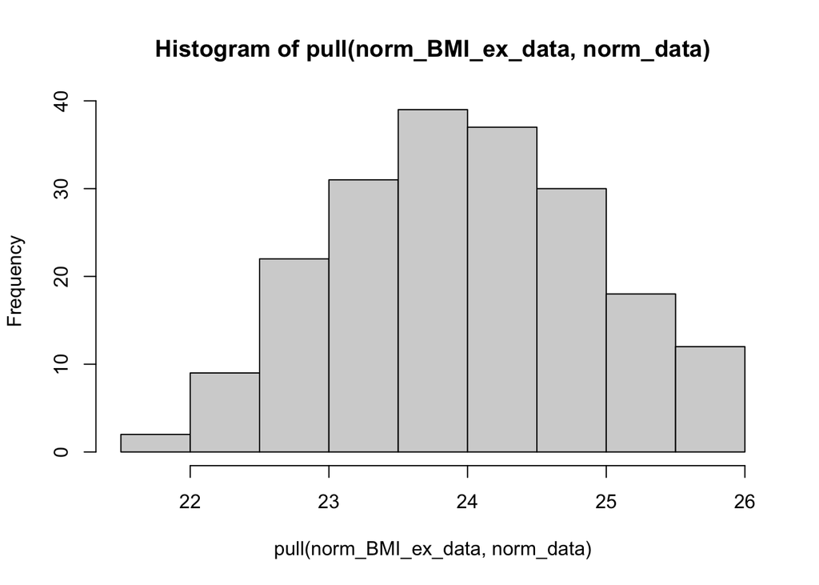

```r
norm_BMI_ex_data <-
  tibble(norm_data = rnorm(n = 200, mean = 24, sd = 1))
hist(pull(norm_BMI_ex_data, norm_data))
```

Here we are simulating 200 observations from a normal distribution with a mean of $m = 24$ and standard deviation of $s = 1$ using the `rnorm()` function.

Alternatively to using base R, we can plot the frequency of simulated observations using the `geom_hist()` function of the `ggplot2` R package. The [ggplot2](https://ggplot2.tidyverse.org/) package creates plots by using layers. Notice in the following code how there is a plus sign between the `ggplot()` function and the `geom_histogram()` function. With `ggplot2` we select what data we would like to plot using the first function (`ggplot()`) and then we add on additional layers of complexity (these layers can even involve different data).

**Click here for additional information on using `ggplot2`.**

The reasons [`ggplot2`](http://ggplot2.tidyverse.org) is generally intuitive for beginners is the use of [grammar of graphics](http://vita.had.co.nz/papers/layered-grammar.html) or the `gg` in `ggplot2`. The idea is that you can construct many sentences by learning just a few nouns, adjectives, and verbs. There are specific “words” that we will introduce, and once you are comfortable with them, you will be able to create (or “write”) hundreds of different plots.

*What is the `ggplot()` function?*

As explained by Hadley Wickham:

> the grammar tells us that a statistical graphic is a mapping from data to aesthetic attributes (colour, shape, size) of geometric objects (points, lines, bars). The plot may also contain statistical transformations of the data and is drawn on a specific coordinates system.

*`ggplot2` Terminology*

- **ggplot** - the main function where you specify the dataset and variables to plot (this is where we define the `x` and `y` variable names)
- **geoms** - geometric objects
  - e.g. `geom_point()`, `geom_bar()`, `geom_line()`, `geom_histogram()`
- **aes** - aesthetics
  - shape, transparency, color, fill, line types
- **scales** - define how your data will be plotted
  - continuous, discrete, log, etc

The function `aes()` is an aesthetic mapping function inside the `ggplot()` object. We use this function to specify plot attributes (e.g. `x` and `y` variable names) that will not change as we add more layers.

Anything that goes in the `ggplot()` object becomes a global setting. From there, we use the `geom` objects to add more layers to the base `ggplot()` object. These will define what we are interested in illustrating using the data.

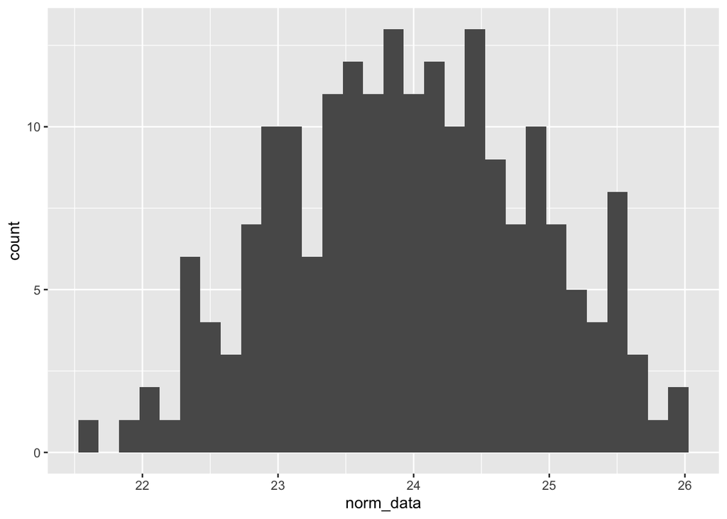

```r
  ggplot2::ggplot(norm_BMI_ex_data, aes(x = norm_data)) +
  ggplot2::geom_histogram()
```

Here, we are using the column called `norm_data` within `norm_BMI_ex_data`. As we noted, with `ggplot2` we must first specify the data to plot with the `ggplot()` function. Then, the `geom_*` function specifies what type of plot to create (e.g. `geom_histogram()` create a histogram).

We could also make this same plot by piping the `norm_BMI_ex_data` data into the `ggplot()` function:

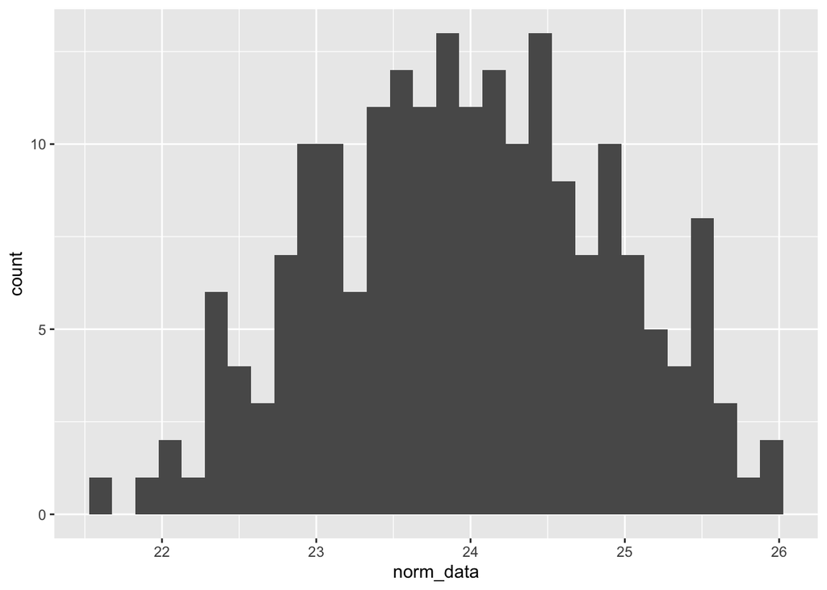

```r
norm_BMI_ex_data %>%
  ggplot2::ggplot(aes(x = norm_data)) +
  ggplot2::geom_histogram()
```

We will see later how we can add many layers to plots with `ggplot2`.

Now instead of using simulated data from a normal distribution, let’s make a histogram of our BMI data:

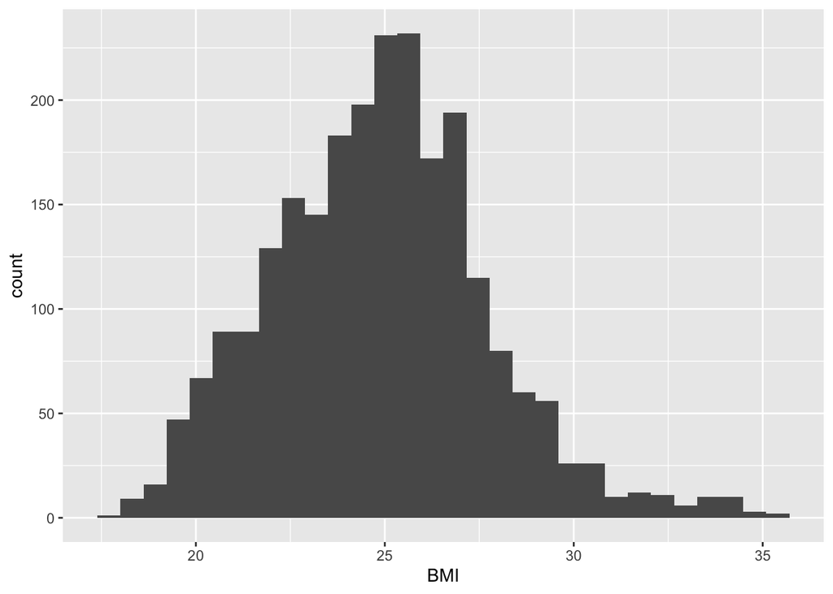

```r
BMI_long %>%
  ggplot(aes(x = BMI)) +
  geom_histogram()
```

Interesting! The data looks like it has one mode, but it does not look completely symmetric. In fact it looks like it might be what is called right skewed. See [here](http://onlinestatbook.com/2/glossary/skew.html) for more information about skewed distributions.

To check we can calculate the mean and median of the BMI data using the base `summarize()` function of the `dplyr` package. If the mean and median are very similar, then we will know that the data isn’t skewed. Note that it is necessary to filter out the NA values first.

```r
BMI_long %>%
  filter(!is.na(BMI))%>%
  summarize(mean = mean(BMI), median = median(BMI))
```

```
# A tibble: 1 × 2
   mean median
  <dbl>  <dbl>
1  24.9   24.9
```

OK, so they are essentially the same, mean= 24.87 and median = 24.9, so this does not fit the hallmark of right-skewed data where the the mean is greater than the median.

However so far we have made a histogram of the BMI data in the long format which combines BMI estimates for different subgroups of people, so rural women, rural men, urban women, urban men, etc. are all combined. If we want to make group comparisons, we need to look at the distributions for the specific groups that we are evaluating. So, we need to pick a particular population of individuals and graph their BMI, for example just the national estimates for women and for men in 1985.

The easiest way to do this is to use some other functions of the `ggplot2` package, particularly the `facet_wrap()` function, which will allow us to look at differences in the distribution of the BMI estimates stratified by `Year`, `Sex`, and `Region`. We can sequentially divide our plots by deeper levels using multiple variables and the `+` plus sign within `facet_wrap()`.

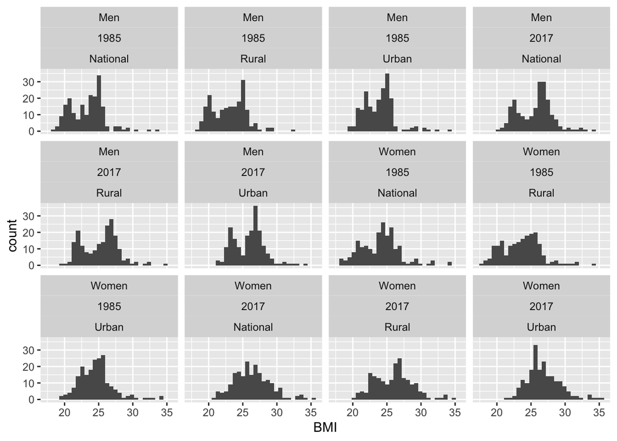

```r
BMI_long %>%
  ggplot(aes(x=BMI)) +
  geom_histogram() +
  facet_wrap(~ Sex + Year + Region)
```

Some of these plots look pretty similar to a normal distribution, like the `Women 2017 Urban` plot (although it might be right-skewed, again we could check the mean and median to determine that). However some of the other plots, like the `Men 2017 Urban` plot, look very different. These plots show what is called a [bimodal distribution](http://onlinestatbook.com/2/introduction/distributions.html), meaning that there appear to be two peaks (or modes), or in other words two different values (and values near each of these) that are the most frequent.

### **Quantile-Quantile Plots**

Another useful plot to create when exploring distributions is something called a “quantile-quantile” plot (or **Q-Q plot** for short). When we talk about a **quantile**, we are talking about dividing up the distribution of the data into roughly equal portions where roughly the same number of observations fall into each portion. For example, if you divide your data into 100 quantiles, you can think about this as percentiles, but you could also divide your data into 10 quantiles and these would be called deciles.

**Why Q-Q plots?** This plot allows us to compare the quantiles of two distributions together: (1) quantiles of a known theoretical distribution (like the normal distribution) compared to (2) quantiles of the distribution of our data. If the quantiles from these two distributions line up in the plot, then that is a visual piece of evidence that our data follow that theoretical distribution (like the normal distribution).

**How does this work?** To do this we will plot the quantiles of our data on the y-axis and the quantiles of the theoretical normal distribution on the x-axis. If the quantiles line up then we can say that our data is fairly normal. See [here](http://onlinestatbook.com/2/advanced_graphs/q-q_plots.html) for more information about Q-Q plots.

Using the `stat_qq()` function of the `ggplot2` package, we can easily create a Q-Q plot for our data randomly sampled from a normal distribution (“sample”) and compare it to the quantiles from a normal distribution (“theoretical”). The default comparison distribution for these functions is the normal distribution, so we don’t need to specify it in our code.

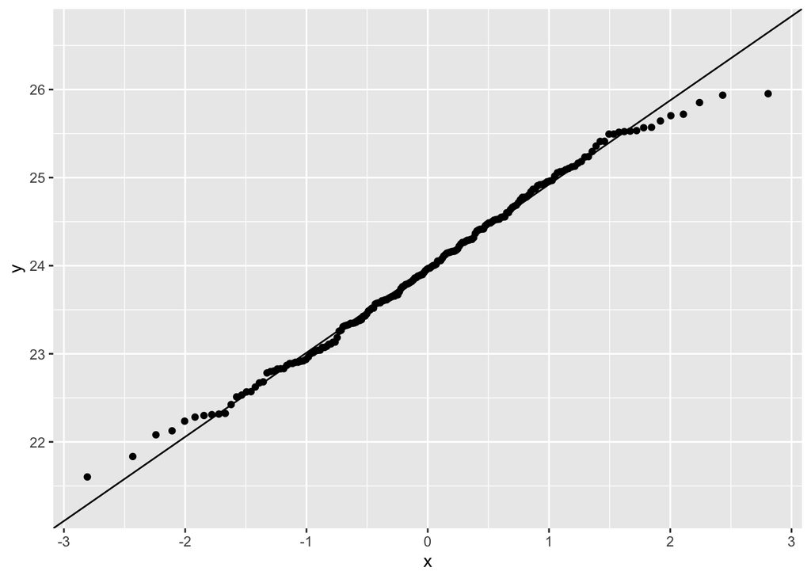

```r
norm_BMI_ex_data %>%
  ggplot(aes(sample = norm_data)) +
  stat_qq() +
  stat_qq_line()
```

The `stat_qq_line()` function is used to add a line (computes the slope an intercept) on the plot. If the points lie on this straight line, this is evidence that the data have a normal distribution, not that the data have a particular normal distribution. Not surprisingly, we see that the points mostly fall on the line, indicating that the quantiles are fairly similar between the observed and theoretical data.

There are some points that are a bit further from the line as we get to the extreme quantiles.

Note that this plot is comparing our `norm_BMI_ex_data` which was randomly sampled from a normal distribution with mean 24 and standard deviation 1 to a *standard normal distribution* with mean 0 and standard deviation 1, which is why the values on the x-axis are -3 to 3 instead of 21 to 27.

As expected we see that about half the points are below our mean of 24 on the y-axis.

We can specify a specific mean and standard deviation for our theoretical distribution in our Q-Q plot; here we specify a normal distribution with mean 24 and standard deviation 1 (so that the theoretical distribution looks more like our data):

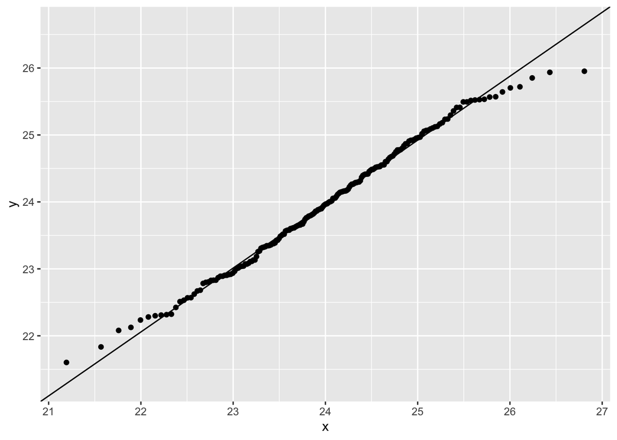

```r
norm_BMI_ex_data %>%
  ggplot(aes(sample = norm_data)) +
  stat_qq(distribution = qnorm, dparams = c(mean = 24, sd = 1)) +
  stat_qq_line(distribution = qnorm, dparams = c(mean = 24, sd = 1))
```

Notice that the plot looks the same except for the values on the x-axis have changed, meaning our interpretation will be the same – it looks like the values are consistent with a normal distribution.

Now, let’s take a look at our actual BMI data:

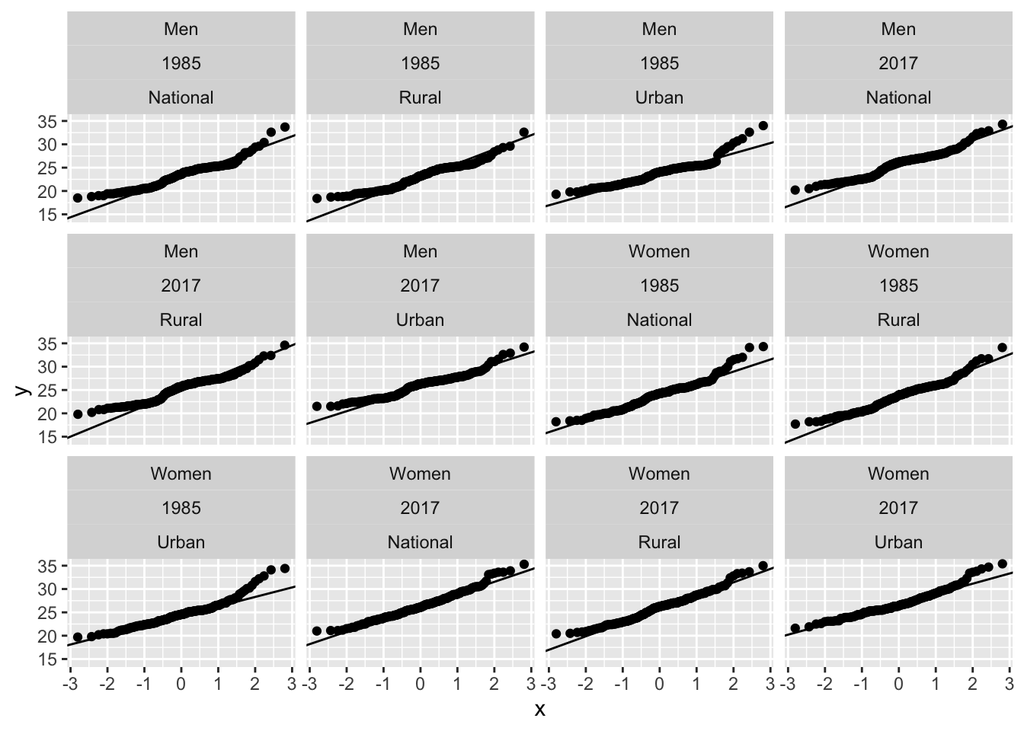

```r
BMI_long %>%
  ggplot(aes(sample =BMI)) +
  stat_qq() +
  stat_qq_line() +
  facet_wrap(~ Sex + Year + Region)
```

This is a little hard to see, some plots suggest those subsets of the data are similar to a normal distribution, but others seem to be skewed. Let’s take a closer look.

For the sake of simplicity, we are going to focus on the subset of data for the women. This is because women were identified in the paper to have fastest increases in BMI over time. If we want to compare two subsets of women (e.g. 1985 versus 2017 or rural versus urban), then we need to look at the distribution of each of these subsets.

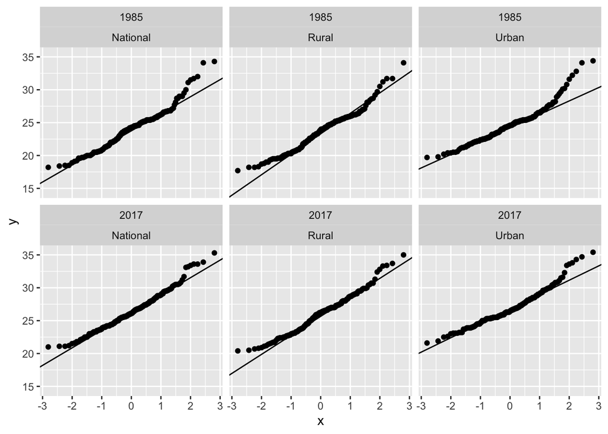

```r
BMI_long %>%
  filter(Sex == "Women") %>%
  ggplot(aes(sample = BMI)) +
  stat_qq() +
  stat_qq_line() +
  facet_wrap(~ Year + Region)
```

We can see that at the extremes of our quantiles, for most of our data, our tails are not very similar to the theoretical distribution. We can can also see that our data is right- or positive-skewed, because the extreme values are above the line.

The rural data looks more normal than the urban data. You might be asking, why do we care if the data look more normal or not? It turns out if you want to ask questions like “Is there a difference in the average BMI estimates from women in 1985 compared to women in 2017?”, we will need to use some of type of statistical test. The most commonly used statistical tests that can answer that question rely on an assumption about the data you have, namely that your data have a similar shape as a theoretical normal distribution. So, if we want to use those powerful statistical tests that rely on this assumption of “normality”, then we need to check that assumption before using those tests.

We can conclude from these plots that the assumption of normality appears to be violated in our data.

## **Data Analysis**

If you have been following along but stopped, we could load our wrangled data like so:

```r
load(here::here("data", "wrangled", "wrangled_data.rda"))
```

**If you skipped the data wrangling section click here.**

First you need to install and load the `OCSdata` package:

```r
install.packages("OCSdata")
library(OCSdata)
```

Then, you may load the wrangled data using the following code:

```r
wrangled_rda("ocs-bp-rural-and-urban-obesity", outpath = getwd())
load(here::here("data", "wrangled", "wrangled_data.rda"))
```

If the package does not work for you, alternatively, an RDA file (stands for R data) of the data can be found [here](https://github.com//opencasestudies/ocs-bp-rural-and-urban-obesity/tree/master/data/wrangled) or slightly more directly [here](https://raw.githubusercontent.com/opencasestudies/ocs-bp-rural-and-urban-obesity/master/data/wrangled/wrangled_data.rda). Download this file and then place it in your current working directory within a subdirectory called “wrangled” within a subdirectory called “data” to copy and paste our code. We used an RStudio project and the [`here` package](https://github.com/jennybc/here_here) to navigate to the file more easily.

```r
load(here::here("data", "wrangled", "wrangled_data.rda"))
```

**Click here to see more about creating new projects in RStudio.**

See [here](https://support.rstudio.com/hc/en-us/articles/200526207-Using-Projects) to learn more about using RStudio projects and here to learn more about the `here` package.

In the previous section, we hinted at the existence of statistical tests to be able to assess if there is a difference in the average BMI estimates between two groups (e.g. national BMI estimates in rural areas and national BMI estimates in urban areas). One such test is the [Student’s $t$-test](https://stattrek.com/statistics/dictionary.aspx?definition=two-sample%20t-test), which can be used to determine if [two group means are different](http://onlinestatbook.com/2/estimation/difference_means.html). However, as mentioned before, this test depends on certain assumption of our data.

In this section, we are going to talk about this test and other tests that do not require the same assumptions about our data.

### **Hypothesis testing**

Let’s remind ourselves of one of our original questions,

> Is there a difference between rural and urban BMI estimates around the world?

In hypothesis testing, we are interested in comparing two different hypotheses: a “null” hypothesis (can be thought of like a baseline e.g. the means between two groups are the same) compared to an “alternative” hypothesis (e.g. the means between two groups are different). We are going to ask if there is enough evidence in our data to reject the null hypothesis.

Let’s try to formalize this a bit.

Suppose we want to test whether there is a difference between rural and urban BMI estimates using the data from 1985. In our case, then, we want to test whether the mean BMI estimate among the rural areas is the same as the mean BMI estimate in the urban areas. If we call the true unknown means of the two groups $\mu_U$ and $\mu_R$, for the urban and rural areas, respectively, then we can define the **null hypothesis** that there is no difference in the two means:

$$H_0: \mu_U = \mu_R$$

In contrast, we also define an **alternative hypothesis** that there is a difference between the mean BMI estimates:

$$H_a: \mu_U \neq \mu_R$$

The idea behind a hypothesis test is that we assume the null hypothesis is true and we use our data to help us identify if there is enough evidence to *reject the null hypothesis*.

This is similar to the idea of assuming that individuals are not guilty until proven otherwise. If there is not enough evidence in the data, then we say we “fail to reject the null hypothesis”.

You might be asking, “But we do not know what the true group means are?” That is correct. Instead, we must estimate these means based on the data that we have. For example, in our data, we can estimate the average BMI estimates for women in rural and urban regions in 1985. Here we will use the `summarize()` function from the `dplyr` package again, this time using the argument `na.rm = TRUE` to remove NA values.

```r
BMI_long %>%
  filter(Year == 1985, Sex == "Women", Region != "National") %>%
  group_by(Region) %>%
  summarize(avg_bmi = mean(BMI, na.rm = TRUE))
```

```
# A tibble: 2 × 2
  Region avg_bmi
  <chr>    <dbl>
1 Rural     23.6
2 Urban     24.6
```

Here we see that that in 1985, the average BMI estimate for women across urban areas is 24.6 compared to 23.6 across rural areas. It looks like BMI estimates are, on average, higher in urban areas compared to rural areas. However, now we want to use a statistical test to assess if this difference is statistically meaningful or a difference of this size could be found due to random chance.

### **Two-sample $t$-test**

The two-sample $t$-test is a common way to determine if the means of two groups are different. It does this by calculating a observed test-statistic, $t$, that looks at the difference in the sample means of the two groups divided by an estimate of the variability in the difference in sample means. Here $s_{pooled}$ is standard deviation of the data when pooling the samples together.
$$t = \frac{\bar{X}_U-\bar{X}_R}{s_{pooled}\sqrt{\frac{1}{n_U} +
\frac{1}{n_R}}}$$
If the null hypothesis is true, and the means for urban and rural areas are the same, then the sample means in the numerator will be similar and this test statistic will be close to 0. However, if the test statistic is not close to 0, this provides evidence the means for the urban and rural areas are difference, and so we may choose to reject the null hypothesis.

To formally decide whether to reject the null hypothesis, we compare the observed test statistic to the distribution of possible test statistics that could occur if the null hypothesis were true using what we call a **p-value**. The p-value tells us the probability of observing a test statistic as or more extreme than the one we observed if the null hypothesis is true. If the p-value is small, say less than 0.05, then our observed test statistic is pretty rare if the null hypothesis is true. This would lead us to reject the null hypothesis and conclude that the means of the two groups are different. We will talk more about p-values, and in particular our choice of 0.05 as a comparison for the p-value, a little later.

Here we perform a two-sample $t$-test comparing estimate for rural women in 1985 to estimates for urban women in 1985. We use the `var.equal = TRUE` option here to use the pooled standard deviation $s_{pooled}$ from the formula above.

```r
t.test(pull(filter(BMI_long, Sex == "Women",
                   Year == "1985",
                   Region == "Rural"), BMI),
       pull(filter(BMI_long, Sex == "Women",
                   Year == "1985",
                   Region == "Urban"), BMI),
       var.equal = TRUE)
```

```
    Two Sample t-test

data:  pull(filter(BMI_long, Sex == "Women", Year == "1985", Region == "Rural"), BMI) and pull(filter(BMI_long, Sex == "Women", Year == "1985", Region == "Urban"), BMI)
t = -3.8952, df = 394, p-value = 0.0001152
alternative hypothesis: true difference in means is not equal to 0
95 percent confidence interval:
 -1.5744694 -0.5182378
sample estimates:
mean of x mean of y
 23.58782  24.63417
```

```r
# means are different - p value <.05 reject the null: no difference in the means
```

In this case the p-value for the test is 0.00012, which is quite small. Here would would reject the null hypothesis that the means in the two groups are equal and conclude there are differences in mean BMI estimates for women in urban and rural areas.

But wait! We need to check the assumptions of the statistical test we used to be sure it is valid. The two-sample $t$-test relies on several **assumptions**:

1. The data for each group is [normally distributed](http://onlinestatbook.com/2/introduction/distributions.html).
2. The variance of both groups is similar.
3. The observations from the two groups are [independent](https://www.stat.cmu.edu/~cshalizi/36-220/lecture-5.pdf) (meaning that observations do not influence each other).
4. The observations within each group are [independent](https://www.stat.cmu.edu/~cshalizi/36-220/lecture-5.pdf) (meaning that observations do not influence each other).

If these assumptions are violated, this doesn’t necessarily mean we can’t perform a statistical test. It just means we may need to consider the following options:

1. If the data isn’t normally distributed, we may need to consider either a [transformation](https://www.statisticshowto.datasciencecentral.com/transformation-statistics/) of the data to make it more normally distributed or a [nonparametric](https://www.mayo.edu/research/documents/parametric-and-nonparametric-demystifying-the-terms/doc-20408960) test which doesn’t rely on the normality assumption.
2. If the variances of the two groups aren’t similar, we can perform a [Welch’s $t$-test](https://www.statisticshowto.datasciencecentral.com/welchs-test-for-unequal-variances/) (also called the unequal variance $t$-test) to account for difference variances. This modifies the denominator of the test statistic to no longer use the standard deviation from pooling the samples. We can do this in `R` by using the `var.equal = FALSE` option in the `t.test()` function.
3. If the data in the two samples are not independent and are instead what we call paired, we should use the [Paired $t$-test](https://www.ncbi.nlm.nih.gov/pmc/articles/PMC5579465/).
4. If the data within a group is not independent, we would need to consider methods beyond the scope of this case study.

Are these assumptions met in our case? We’ve already seen, using Q-Q plots, that these BMI estimates may not be normally distributed. We haven’t checked the assumption of equal variance yet. But it seems clear that the last assumption (of independent samples) is violated in our case! The BMI data for rural areas comes from the same countries and the BMI data for urban areas, meaning the samples are not independent and are instead what we call [paired](https://www.ncbi.nlm.nih.gov/pmc/articles/PMC5579465/). We need to account for this because paired values may be more similar to one another because they come from the same country. Note that this would also be true for the male and female measurements from the same country or the values in the same countries from 1985 and later in 2017.

### **Paired $t$-test**

When we perform a paired $t$-test, instead of looking at the means of the two samples separately, we combine observations in a pair (from the same country in our case) to calculate a difference in values between the two samples. For example, we are really testing the `bmi_diff` column in the data below:

```r
BMI_long %>%
  filter(Year == 1985, Sex == "Women", Region != "National") %>%
  group_by(Country) %>%
  summarize(bmi_rural = BMI[Region == "Rural"],
            bmi_urban = BMI[Region == "Urban"],
            bmi_diff = bmi_rural - bmi_urban)
```

```
# A tibble: 200 × 4
   Country             bmi_rural bmi_urban bmi_diff
   <chr>                   <dbl>     <dbl>    <dbl>
 1 Afghanistan              20.1      23.2   -3.10
 2 Albania                  26.1      25.9    0.200
 3 Algeria                  23.3      24.8   -1.5
 4 American Samoa           34.1      34.4   -0.300
 5 Andorra                  25.4      25.2    0.200
 6 Angola                   20.9      22.7   -1.8
 7 Antigua and Barbuda      24        25.4   -1.40
 8 Argentina                23.3      24.5   -1.2
 9 Armenia                  25.2      25.5   -0.300
10 Australia                24.7      24.4    0.300
# ℹ 190 more rows
```

This means our hypotheses are slightly different from the two-sample $t$-test. In this case we are testing the differences among the pairs of observations and how close these differences are to zero. (A mean difference of zero would mean the BMI estimates are the same in the rural and urban areas.) If we let $\mu_d$ represent the true mean difference between the paired observations of the two groups, then our null hypothesis is that the mean of the differences is equal to zero:
$$H_0 : \mu_d = 0$$

And the alternative hypothesis is that the mean of the differences is not equal to zero:
$$H_a : \mu_d \neq 0$$

We can perform a paired $t$-test by adding the option `paired = TRUE` to the `t.test()` command. Note that we don’t need to specify anything about equality of variances now, because there is only one variance, the variance of the paired differences!

```r
t.test(pull(filter(BMI_long, Sex == "Women",
                   Year == "1985",
                   Region == "Rural"), BMI),
       pull(filter(BMI_long, Sex == "Women",
                   Year == "1985",
                   Region == "Urban"), BMI),
       paired = TRUE)
```

```
    Paired t-test

data:  pull(filter(BMI_long, Sex == "Women", Year == "1985", Region == "Rural"), BMI) and pull(filter(BMI_long, Sex == "Women", Year == "1985", Region == "Urban"), BMI)
t = -14.095, df = 195, p-value < 2.2e-16
alternative hypothesis: true mean difference is not equal to 0
95 percent confidence interval:
 -1.1870263 -0.8956268
sample estimates:
mean difference
      -1.041327
```

```r
# means are different - p value <.05 reject the null: no difference in the means
```

Question opportunity: Looking at the t value, was global BMI lower in Rural or Urban areas in 1985?

Let’s come back to the other $t$-test assumptions now. With a paired $t$-test, we no longer need to assess the assumption about equal variance, since we are really testing the mean of one sample (of paired differences) rather than comparing two samples. However, we still have to check normality and independence of observations. We can rephrase these now to be about the paired differences rather than the two separate samples:

1. The paired differences are [normally distributed](http://onlinestatbook.com/2/introduction/distributions.html).
2. The paired differences are [independent](https://www.stat.cmu.edu/~cshalizi/36-220/lecture-5.pdf) (meaning that observations do not influence each other).

If we assume that measurements between different countries are independent, this second assumption is not violated. Therefore, we only now need to check normality of these paired differences.

We can start by making a Q-Q plot of the paired differences.

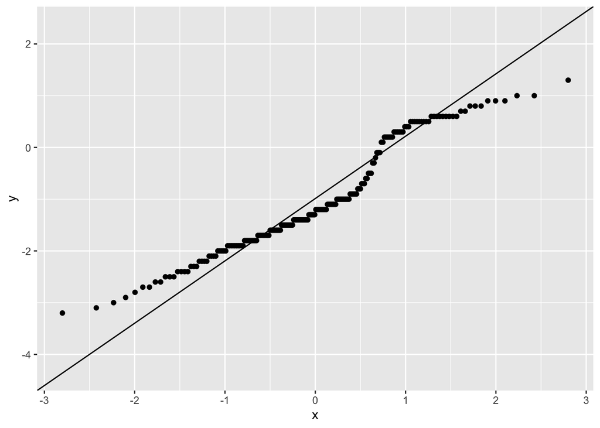

```r
BMI_long %>%
  filter(Year == 1985, Sex == "Women", Region != "National") %>%
  group_by(Country) %>%
  summarize(bmi_rural = BMI[Region == "Rural"],
            bmi_urban = BMI[Region == "Urban"],
            bmi_diff = bmi_rural - bmi_urban)  %>%
  ggplot(aes(sample = bmi_diff)) +
  stat_qq() +
  stat_qq_line()
```

We see that these paired differences do not appear to be normally distributed because the points do not lie on the straight line. We can also see this by making a histogram of these paired differences:

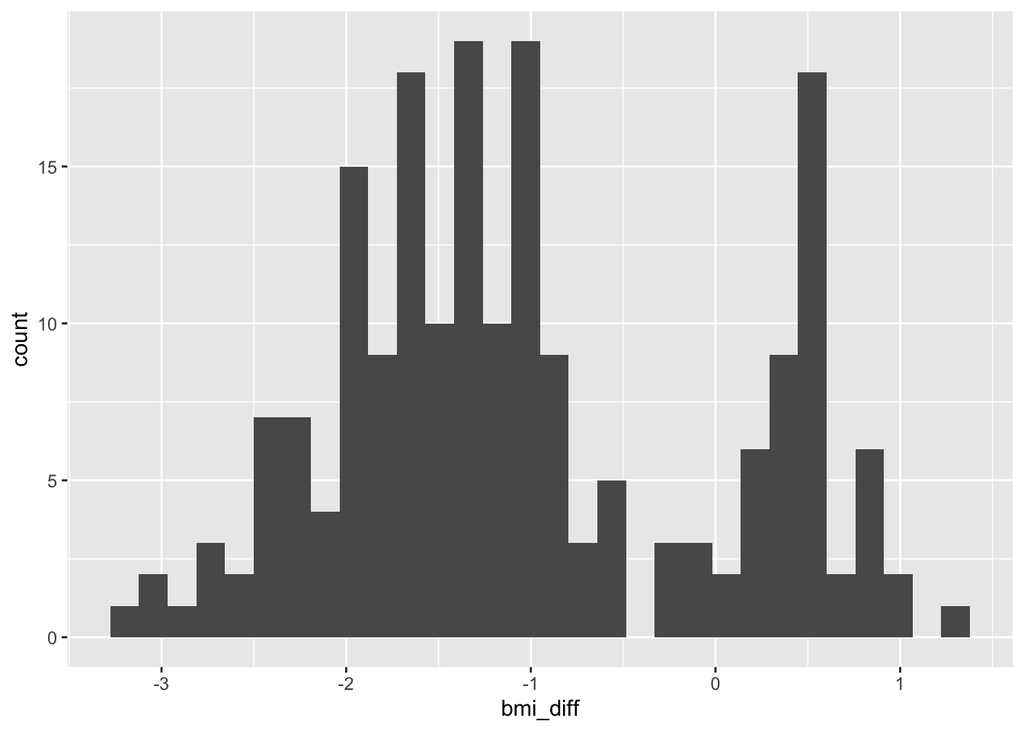

```r
BMI_long %>%
  filter(Year == 1985, Sex == "Women", Region != "National") %>%
  group_by(Country) %>%
  summarize(bmi_rural = BMI[Region == "Rural"],
            bmi_urban = BMI[Region == "Urban"],
            bmi_diff = bmi_rural - bmi_urban)  %>%
  ggplot(aes(x = bmi_diff)) +
  geom_histogram()
```

This histogram appears to show show a bimodal distribution, meaning two groups of countries – most countries have a rural BMI estimates lower than urban BMI estimates (`bmi_diff` < 0), while a smaller group of countries have urban BMI estimates higher than urban BMI estimates (`bmi_diff` >0).

First we will try transform our data to make it more normally distributed. One way to do this is to take the logarithm of the data values. Logarithms make extreme values less extreme, so can be helpful when data has a right skew.

```r
# create a new dataset with the paired differences
# create a log version of the difference variable using mutate()
BMI_diff_log <- BMI_long %>%
  filter(Year == 1985, Sex == "Women", Region != "National") %>%
  group_by(Country) %>%
  summarize(bmi_rural = BMI[Region == "Rural"],
            bmi_urban = BMI[Region == "Urban"],
            bmi_diff = bmi_rural - bmi_urban) %>%
  mutate(log_diff=log(bmi_diff))
```

Notice the warning message that `In log(bmi_diff) : NaNs produced`. This is because some of our differences were less than zero, and the logarithm of a negative number is not defined. We can fix this issue by adding the same positive number, say 5, to each difference before taking the logarithm:

```r
BMI_diff_log <- BMI_long %>%
  filter(Year == 1985, Sex == "Women", Region != "National") %>%
  group_by(Country) %>%
  summarize(bmi_rural = BMI[Region == "Rural"],
            bmi_urban = BMI[Region == "Urban"],
            bmi_diff = bmi_rural - bmi_urban) %>%
  mutate(log_diff=log(bmi_diff + 5))
```

Let’s look at a Q-Q plot and histogram of this transformed data:

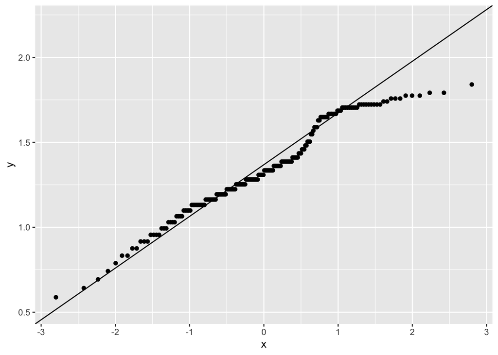

```r
BMI_diff_log %>%
  ggplot(aes(sample = log_diff)) +
  stat_qq() +
  stat_qq_line()
```

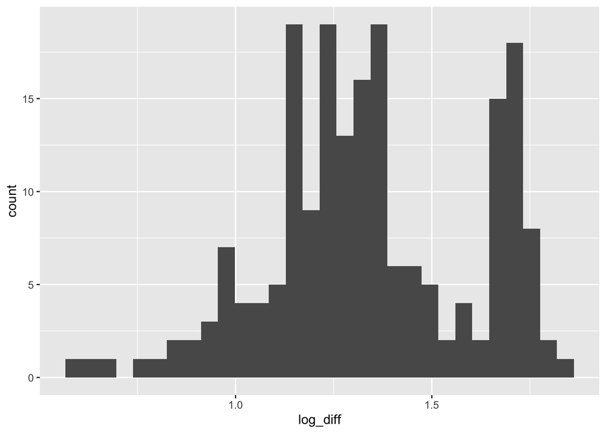

```r
BMI_diff_log %>%
  ggplot(aes(x = log_diff)) +
  geom_histogram()
```

The transformed data still does not appear to be normally distributed and the bimodal nature of the distribution is still apparent in the histogram. What should we do? The $t$-test is fairly **robust** to violations of the normality assumption if the sample size is relatively large, due to what is called the [central limit theorem](https://www.analyticsvidhya.com/blog/2019/05/statistics-101-introduction-central-limit-theorem/), which states that as samples get larger, the sample mean has an approximate normal distribution.

With our sample size of 200, we could consider using the paired $t$-test even with our non-normal data. However, if we had a smaller sample, we might still need to consider another alternative since the log-transformed data still doesn’t look normal. We might want to consider a non-parametric test in that case.

### **Nonparametric tests**

When the normality assumption of a paired $t$-test is violated, we can consider a nonparametric alternative instead. What’s a non-parametric test? **Parametric tests** are based on assumptions about the distribution of the underlying data, while **nonparametric tests** do not rely on these distributional assumptions.

See [here](https://www.mayo.edu/research/documents/parametric-and-nonparametric-demystifying-the-terms/doc-20408960) for more information about the difference between these two classes of tests.

The nonparametric alternative to the paired $t$-test is called the [Wilcoxon signed-rank test](http://www.biostathandbook.com/wilcoxonsignedrank.html). This test doesn’t require the same normality assumption as the $t$-test, so can be considered with the data does not appear to be normally distributed and particularly when the number of samples is low. The null hypothesis for this test is that the **median** of the paired differences is 0.

To do a Wilcoxon test, we use the `wilcox.test()` function:

```r
wilcox.test(pull(filter(BMI_long, Sex == "Women",
                        Year == "1985",
                        Region == "Rural"), BMI),
           pull(filter(BMI_long, Sex == "Women",
                       Year == "1985",
                       Region == "Urban"), BMI),
           paired = TRUE)
```

```
    Wilcoxon signed rank test with continuity correction

data:  pull(filter(BMI_long, Sex == "Women", Year == "1985", Region == "Rural"), BMI) and pull(filter(BMI_long, Sex == "Women", Year == "1985", Region == "Urban"), BMI)
V = 1562, p-value < 2.2e-16
alternative hypothesis: true location shift is not equal to 0
```

With this nonparametric test, we still see a small p-value, indicating that BMI estimates between urban and rural areas are different. We would conclude that there’s a difference in the median BMI estimates between these types of regions.

### **Multiple Testing Correction**

Let’s take a look back at the questions we wanted to answer: 1) Is there a difference between rural and urban BMI estimates around the world? In particular, how does this look for females? 2) How have BMI estimates changed from 1985 to 2017? Again, In particular, how does this look for females? 3) How do different countries compare for BMI estimates? In particular, how does the United States compare to the rest of the world?

It’s important to note that ultimately we wanted to test 4 different tests to answer question 1 and 2:

1. Is there a difference in mean BMI for women between Rural and Urban areas in 1985?
2. Is there a difference in mean BMI for women between Rural and Urban areas in 2017?
3. Is there a difference in mean BMI for women between 1985 and 2017 in Rural areas?
4. Is there a difference in mean BMI for women between 1985 and 2017 in Urban areas?

So far we have only looked at the first test. Let’s perform all 4 of these tests using the non-parametric Wilcoxon signed-rank test:

```r
wilcox.test(pull(filter(BMI_long, Sex == "Women",
                        Year == "1985",
                        Region == "Rural"), BMI),
           pull(filter(BMI_long, Sex == "Women",
                       Year == "1985",
                       Region == "Urban"), BMI),
           paired = TRUE)
```

```
    Wilcoxon signed rank test with continuity correction

data:  pull(filter(BMI_long, Sex == "Women", Year == "1985", Region == "Rural"), BMI) and pull(filter(BMI_long, Sex == "Women", Year == "1985", Region == "Urban"), BMI)
V = 1562, p-value < 2.2e-16
alternative hypothesis: true location shift is not equal to 0
```

```r
wilcox.test(pull(filter(BMI_long, Sex == "Women",
                        Year == "2017",
                        Region == "Rural"), BMI),
           pull(filter(BMI_long, Sex == "Women",
                       Year == "2017",
                       Region == "Urban"), BMI),
           paired = TRUE)
```

```
    Wilcoxon signed rank test with continuity correction

data:  pull(filter(BMI_long, Sex == "Women", Year == "2017", Region == "Rural"), BMI) and pull(filter(BMI_long, Sex == "Women", Year == "2017", Region == "Urban"), BMI)
V = 2750.5, p-value < 2.2e-16
alternative hypothesis: true location shift is not equal to 0
```

```r
wilcox.test(pull(filter(BMI_long, Sex == "Women",
                        Year == "1985",
                        Region == "Rural"), BMI),
           pull(filter(BMI_long, Sex == "Women",
                       Year == "2017",
                       Region == "Rural"), BMI),
           paired = TRUE)
```

```
    Wilcoxon signed rank test with continuity correction

data:  pull(filter(BMI_long, Sex == "Women", Year == "1985", Region == "Rural"), BMI) and pull(filter(BMI_long, Sex == "Women", Year == "2017", Region == "Rural"), BMI)
V = 273, p-value < 2.2e-16
alternative hypothesis: true location shift is not equal to 0
```

```r
wilcox.test(pull(filter(BMI_long, Sex == "Women",
                        Year == "1985",
                        Region == "Urban"), BMI),
           pull(filter(BMI_long, Sex == "Women",
                       Year == "2017",
                       Region == "Urban"), BMI),
           paired = TRUE)
```

```
    Wilcoxon signed rank test with continuity correction

data:  pull(filter(BMI_long, Sex == "Women", Year == "1985", Region == "Urban"), BMI) and pull(filter(BMI_long, Sex == "Women", Year == "2017", Region == "Urban"), BMI)
V = 189, p-value < 2.2e-16
alternative hypothesis: true location shift is not equal to 0
```

In each of these tests, the very small p-value that would lead us to conclude that there is a difference between the two groups we are comparing. However, when we test multiple questions like this, we need to correct for the multiple tests that we are performing.

The more we test data, the more likely we are to see a significant finding just by [random chance](https://online.stat.psu.edu/stat200/lesson/6/6.1) even when the finding is in fact not real. It all comes down to probability.

#### Probability

You may recall that probability is the chance that an event will happen and it ranges from 0 to 1. You can also think of it as a percentage of 0% (probability =0) to 100% (probability = 1) of chance that an event will happen.

[figure not shown]

[[source](https://www.mathsisfun.com/data/images/probability-line.svg)]

If we consider flipping a coin, the probability of an event happening (heads) is always equal to 1 ( or 100% chance) minus the probability of the event not happening (tails instead of heads) because the total probability can not exceed 100%.

```
    probability of 1 (100% chance) = the probability of heads (50% chance)
                                     + the probability of tails (50% chance)

                                 1 = P(heads) + P(tails)
        probability of one outcome = 1 - the probability of the other outcome
                          P(heads) = 1 - P(tails)
                                    or
                          P(tails) = 1 - P(heads)
```

If we think about the probability of getting significant or nonsignificant results we can think of it like this:

```
                                 1 = P(significant results)
                                      + P(no significant results)
            P(significant results) = 1 - P(no significant results)
```

### **Alpha**

Alpha is the amount of risk that you are willing to accept that a statistical test result is actually a false positive, in other words we reject the null hypothesis when the null hypothesis is true. This is also called [type 1 error](https://web.ma.utexas.edu/users/mks/statmistakes/errortypes.html). A significance threshold of .05 is customary and it means that we are accepting a 5% chance that our result is actually a false positive.

```
                             alpha = probability of false significant results
                                       or
                                 α = P(Making a type 1 error)
```

Remember that in our statistical tests if the p-value < alpha it is considered significant and if p-value > alpha it is considered not significant

But what really is the [p-value](https://towardsdatascience.com/p-values-explained-by-data-scientist-f40a746cfc8)?

### **p-values**

The p in p-value stands for **probability** - the probability of observing a test statistic (for example the t in our student $t$-tests based on the means of our groups of comparison) as or more extreme than what we observe if the null hypothesis is true (continuing with the t test example, the distribution of possible t statistics if there is no difference between groups). Therefore a p-value of 0.02 means that there is a 2 percent chance that our data may also look the way it does if the null hypothesis is true. This does not mean there is a 2% chance that the null hypothesis is true. It only means that there is a 2% chance we would observe data as extreme as ours if there really is no difference between the groups.

So then if alpha is the threshold for the p-value for obtaining false significant results then the probability of not making incorrect conclusions is 1 - alpha:

```
             P(Not making a type 1 error) = 1 - α
```

```r
#P(Not making a type 1 error) = 1 - α
1-.05
```

```
[1] 0.95
```

OK so if we use an alpha of .05 we are accepting that 95% of the time we will not make a Type 1 error and 5 % of the time we will just by random chance.  
Taking this one step further:

```
                 P(Making an error) = 1 - P(Not making an error)
                 P(Making an error) = 1 - (1 - α)
```

Here we can see that this checks out:

```r
#P(Making an error) = 1 - (1 - α)
1-(1-.05)
```

```
[1] 0.05
```

So what happens if we perform multiple tests?

The probability of not making a type 1 error would remain the same for each test. Therefore we need to multiply the probabilities together each time to determine the over all probability of making an error across multiple tests. See [here](http://mathforum.org/library/drmath/view/74065.html) about why we multiply probabilities together.

```
    P(Not making an error in m tests) = (1 - α)^m
P(Making at least 1 error in m tests) = 1 - (1 - α)^m
```

Let’s consider if we performed 10 different statistical tests and if we as usual considered the significance threshold alpha of .05:

So the probability of getting 1 significant result with 10 tests is:

```r
#P(Making at least 1 error in 10 tests) = 1 - ((1 - α)(1 - α)(1 - α)(1 - α)(1 - α)(1 - α)(1 - α)(1 - α)(1 - α)(1 - α))
#this is the same as:
#P(Making at least 1 error in 10 tests) = 1 - (1 - α)^10
 1- (1-.05)^10
```

```
[1] 0.4012631
```

So there is a 40% chance that that there will be a significant finding simply due to random chance alone.

What about 100 tests?

```r
#P(Making at least 1 error in 100 tests) = 1 - (1 - α)^100
 1- (1-.05)^100
```

```
[1] 0.9940795
```

Yikes!! That is almost a 100% chance that there will be a significant finding simply due to chance alone!

Much of this explanation is described in this [lecture](https://online.stat.psu.edu/stat200/lesson/6/6.3).

One way to correct for this is multiple testing issue is using the [Bonferroni method](http://mathworld.wolfram.com/BonferroniCorrection.html).

In this method we would divide our significance threshold (generally 0.05) by the number of tests.

```r
.05/4 # 4 tests
```

```
[1] 0.0125
```

Our new significance threshold is now 0.0125. Thus our p-values should be less than this value for us to reject the null that there is no difference in means. In our 4 Wilcoxon tests, our p-values were less than 0.0125. So we see a significant difference in the means of the groups after multiple testing correction for our four different tests.

## **Data Visualization**

If you have been following along but stopped, we could load our wrangled data like so:

```r
load(here::here("data", "wrangled", "wrangled_data.rda"))
```

**If you skipped the data wrangling section click here.**

First you need to install and load the `OCSdata` package:

```r
install.packages("OCSdata")
library(OCSdata)
```

Then, you may load the wrangled data using the following code:

```r
wrangled_rda("ocs-bp-rural-and-urban-obesity", outpath = getwd())
load(here::here("data", "wrangled", "wrangled_data.rda"))
```

If the package does not work for you, alternatively, an RDA file (stands for R data) of the data can be found [here](https://github.com//opencasestudies/ocs-bp-rural-and-urban-obesity/tree/master/data/wrangled) or slightly more directly [here](https://raw.githubusercontent.com/opencasestudies/ocs-bp-rural-and-urban-obesity/master/data/wrangled/wrangled_data.rda). Download this file and then place it in your current working directory within a subdirectory called “wrangled” within a subdirectory called “data” to copy and paste our code. We used an RStudio project and the [`here` package](https://github.com/jennybc/here_here) to navigate to the file more easily.

```r
load(here::here("data", "wrangled", "wrangled_data.rda"))
```

**Click here to see more about creating new projects in RStudio.**

See [here](https://support.rstudio.com/hc/en-us/articles/200526207-Using-Projects) to learn more about using RStudio projects and here to learn more about the `here` package.

Again we will utilize `ggplot2` to create plots to look at the directional and magnitude of the differences in BMI we are interested in. If you need additional information please see the [Data Exploration section](https://www.opencasestudies.org/ocs-bp-rural-and-urban-obesity/#Distribution/#:~:text=Click%20here%20for%20additional%20information%20on%20using%20ggplot2.) earlier in this case study. The top two lines of the code for the following plots, filter the data to only specific values of interest. Then we layer what is called a jitter on top of a box plot. A jitter is essentially a dot plot but with some variation on the location of the points so that they do not line up vertically which can make the individual points difficult to see.

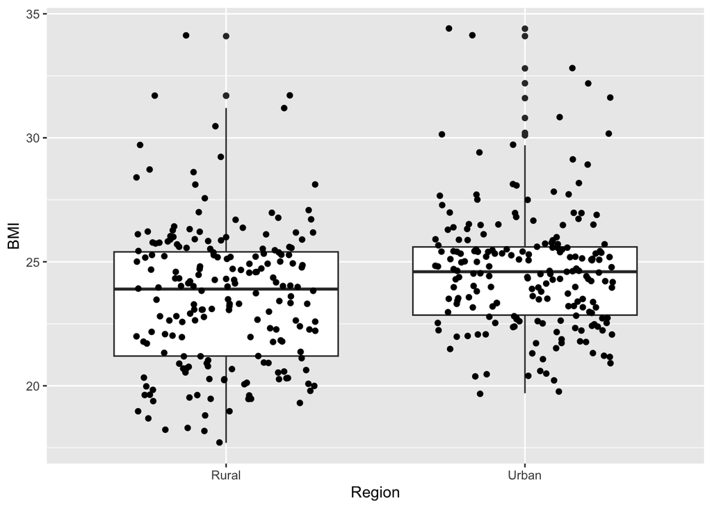

```r
BMI_long %>%
  filter(Sex == "Women",
         Year == "1985",
         Region != "National") %>%
  ggplot(aes(x = Region, y = BMI)) +
  geom_boxplot() +
  geom_jitter(width = .3)
```

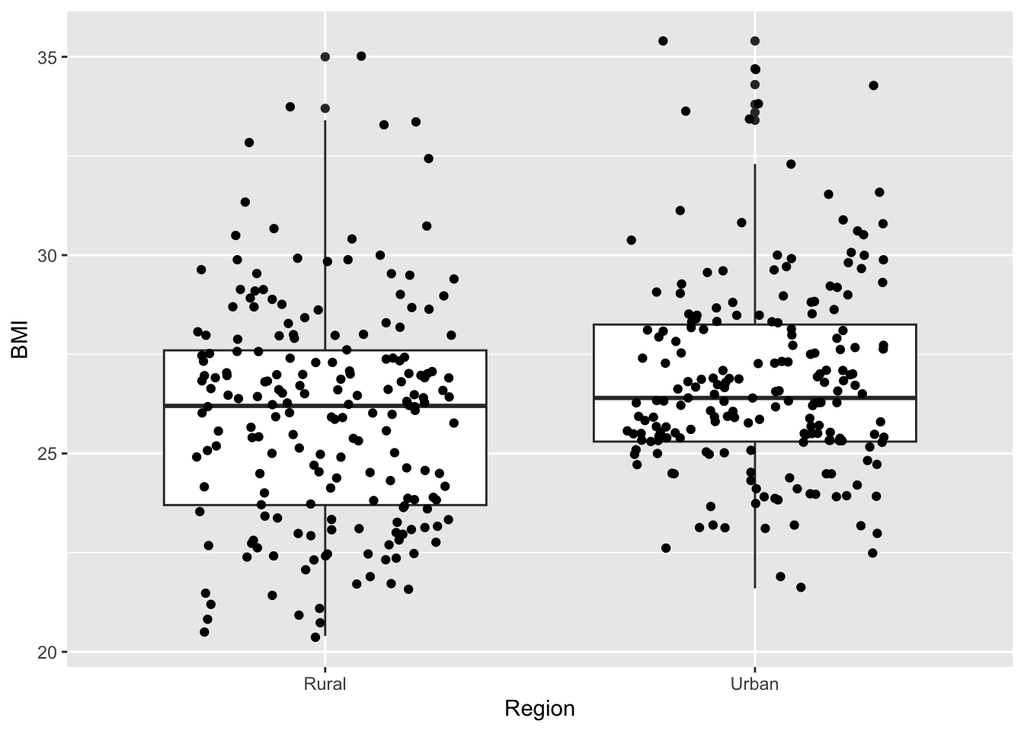

```r
# the width determines how wide the points are plotted

BMI_long %>%
  filter(Sex == "Women",
         Year == "2017",
         Region != "National") %>%
  ggplot(aes(x = Region, y = BMI)) +
  geom_boxplot() +
  geom_jitter(width = .3)
```

Our 2nd main question was: How have BMI estimates changed from 1985 to 2017? Let’s look at the change in rural and urban mean BMI estimates over time:

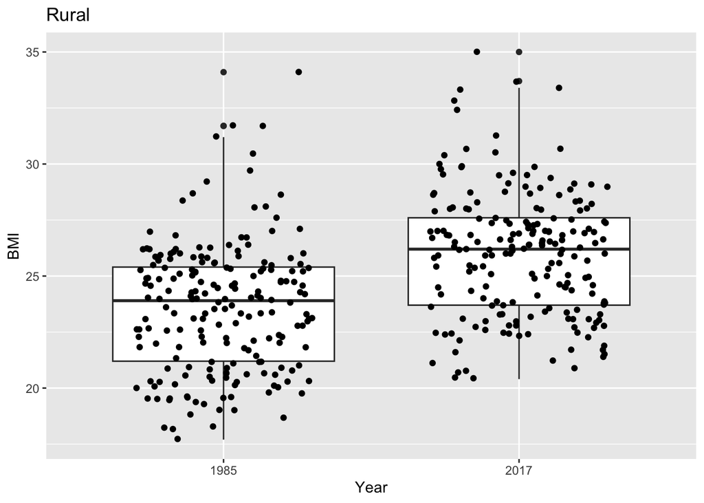

```r
#this time we will add titles for Rural and Urban using ggtitle()
BMI_long %>%
  filter(Sex == "Women",
         Year %in% c("1985", "2017"),
         Region == "Rural") %>%
  # filtering this way allows us to keep data from both years
  ggplot(aes(x = Year, y = BMI)) +
  geom_boxplot() +
  geom_jitter(width = .3) +
  ggtitle("Rural")
```

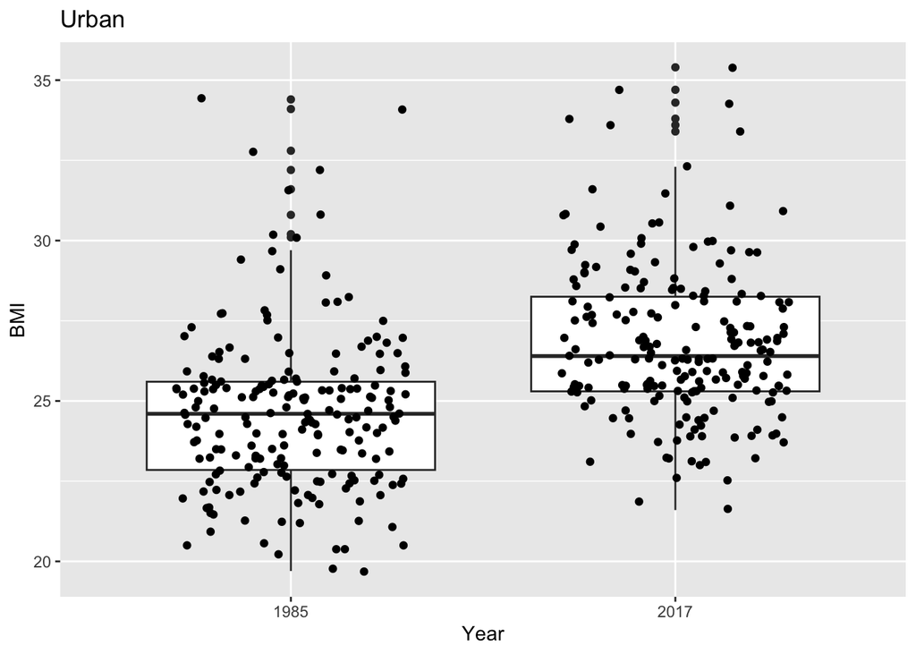

```r
BMI_long %>%
  filter(Sex == "Women",
         Year %in% c("1985", "2017"),
         Region == "Urban") %>%
  ggplot(aes(x = Year, y = BMI)) +
  geom_boxplot() +
  geom_jitter(width = .3) +
  ggtitle("Urban")
```

Let’s put the plots together to see how the change over the years differs between the regions. We will use again use `facet_wrap()` to do this:

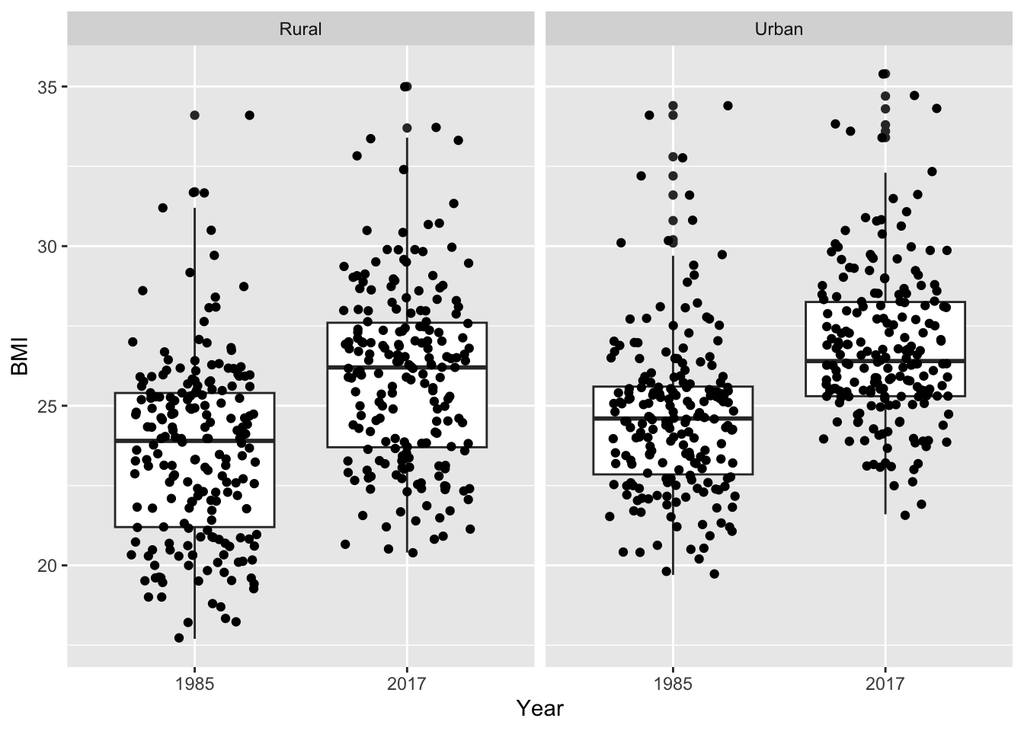

```r
BMI_long %>%
  filter(Sex == "Women",
         Year %in% c("1985", "2017"),
         Region %in% c("Rural", "Urban")) %>%
  # filtering this way allows us to keep data from both years
  ggplot(aes(x = Year, y = BMI)) +
  geom_boxplot() +
  geom_jitter(width = .3) +
  facet_wrap(~ Region)
```

```r
# we would also get national data without `Region %in% c("Rural", "Urban"))`
```

Indeed the change in BMI over time looks bigger in the rural areas!

One third main questions was: How do the different countries compare? Or in other words what do the individual dots represent in our box plots? We will take a look using `geom_label()`:

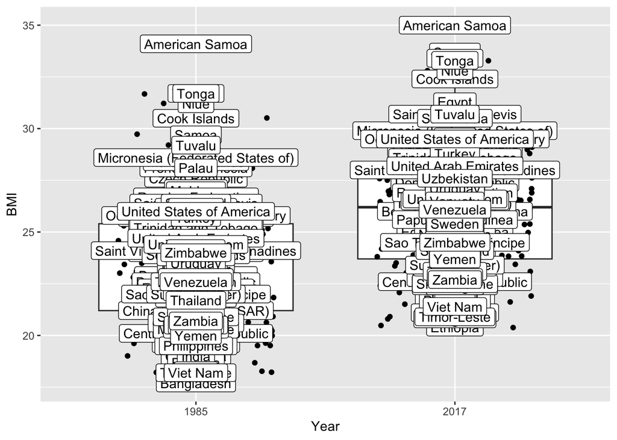

```r
BMI_long %>%
  filter(Sex == "Women",
         Year %in% c("1985", "2017"),
         Region == "Rural") %>%
  ggplot(aes(x = Year, y = BMI)) +
  geom_boxplot() +
  geom_jitter(width = .3) +
  geom_label(aes(label = Country))
```

If we include all country names this is a bit too much… so perhaps we should focus on just the extreme BMI values using `filter()` function of the`dplyr` package. We will also use the `ggrepel` package to have our labels not overlap each other.

Part of the third question was: How does the United States of America compare? So let’s label the data points for the United states.

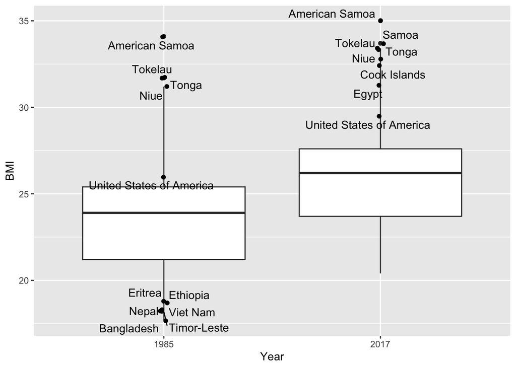

```r
BMI_long %>%
  filter(Sex == "Women",
         Year %in% c("1985", "2017"),
         Region == "Rural") %>%
  ggplot(aes(x = Year, y = BMI)) +
  geom_boxplot() +
  geom_jitter(data=BMI_long %>%
              filter(Sex == "Women",
                     Year %in% c("1985", "2017"),
                     Region == "Rural") %>%
              filter(BMI>31 | BMI<19 | Country == "United States of America"),
              aes(x =Year, y =BMI),
              width = .02) +
  ggrepel::geom_text_repel(data=BMI_long %>%
              filter(Sex == "Women",
                     Year %in% c("1985", "2017"),
                     Region == "Rural") %>%
              filter(BMI>31 | BMI<19 | Country == "United States of America"),
              aes(x =Year, y =BMI, label = Country))
```

And let’s fill the box plots with color and outline in black:

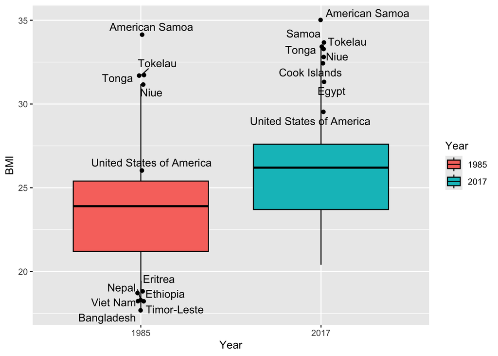

```r
BMI_long %>%
  filter(Sex == "Women",
         Year %in% c("1985", "2017"),
         Region == "Rural") %>%
  ggplot(aes(x = Year, y = BMI)) +
  geom_boxplot(outlier.shape = NA, color = "black", aes(fill = Year)) +
  geom_jitter(data=BMI_long %>%
              filter(Sex == "Women",
                     Year %in% c("1985", "2017"),
                     Region == "Rural") %>%
              subset(BMI>31 | BMI<19 | Country == "United States of America"),
              aes(x =Year, y =BMI),
              width = .02) +
  ggrepel::geom_text_repel(data=BMI_long %>%
              filter(Sex == "Women",
                     Year %in% c("1985", "2017"),
                     Region == "Rural") %>%
              subset(BMI>31 | BMI<19 | Country == "United States of America"),
              aes(x =Year, y =BMI, label = Country))
```

### **Overall differences**

Let’s take a look at all the data together, including the data for men:

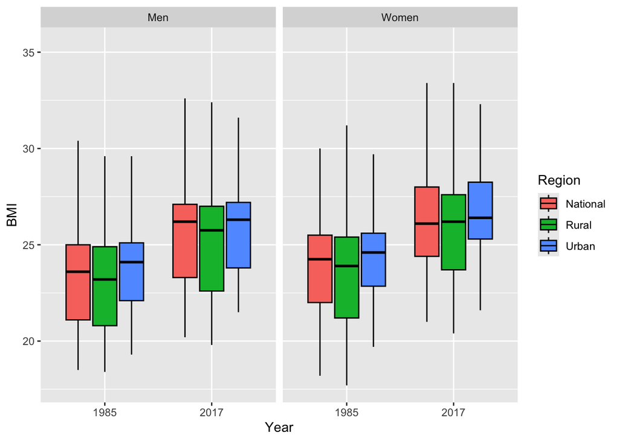

```r
ggplot(BMI_long, aes(x = Year, y = BMI, col = Region)) +
  geom_boxplot(outlier.shape = NA, color = "black" , aes(fill = Region)) +
  facet_grid(~ Sex)
```

That’s useful, but let’s look at the individual points and include our country labels, to do so lets change our United States of America label to USA:

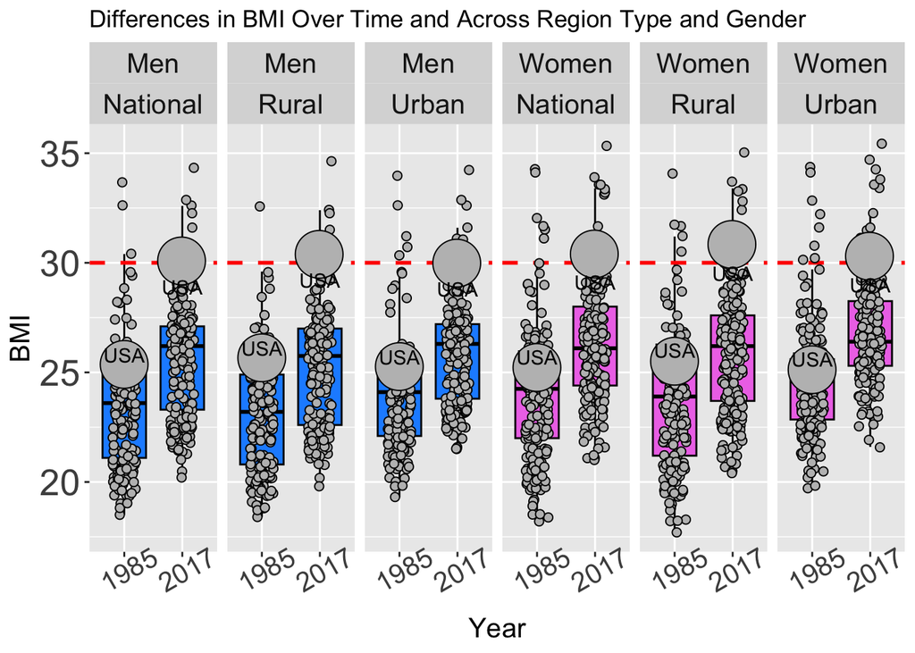

```r
BMI_long[["Country"]] <-BMI_long[["Country"]] %>%
  str_replace( pattern = "United States of America", replacement = "USA")


ggplot(BMI_long, aes(x = Year, y = BMI, col = Year)) +
  geom_boxplot(outlier.shape = NA, color = "black" , aes(fill = Sex)) +
  facet_grid(~ Sex + Region) +
  geom_hline(yintercept=30, linetype="dashed", color = "red", size =1) +
  # This will add a horizontal dashed line to indicate the obesity BMI threshold
  geom_jitter(data=subset(BMI_long),
              aes(x =Year, y =BMI),
              width = .2, size =2, shape =21, color = "black", fill = "gray") +
  # This will add the individual country data points
  # The shape 21 allows for a different fill and outline color
  # The width determines how wide the jitter points are plotted
  geom_jitter(data=subset(BMI_long, Country == "USA"),
              aes(x =Year, y =BMI),
              width = .02, size =12, shape =21, color = "black", fill = "gray") +
  # This will add points that are larger for the USA data
  geom_text(data=subset(BMI_long,  Country == "USA"),
            aes(x =Year, y =BMI,label=Country),
            color = "black") +
  # This will add USA labels to the USA points
  theme(legend.position = "none",
  # This is useful for removing the legend
        axis.text.x = element_text(size = 15,angle = 30),
        # this changes the size and angle of the x axis point labels
        axis.text.y = element_text(size = 20),
        axis.title.y = element_text(size =15),
        axis.title.x = element_text(size =15),
        strip.text.x = element_text(size = 15)) +
  # This changes the size of x axis labels for the facet
        ggtitle( "Differences in BMI Over Time and Across Region Type and Gender") +
  # Add a  plot title
        scale_fill_manual(values=c("dodgerblue", "orchid2"))
```

Here we can see that overall BMI appears to be increasing globally over time. Additionally we can see that this is occurring not just in urban areas, but also in rural areas. The US is consistently above the median in all strata of the data. In general, the female data shows higher BMI values than the male data. The rural USA BMI appears to be higher than the urban BMI for both men and women. Many countries have average BMI estimates above the obesity threshold of 30. Thus it appears that education and outreach programs for weight management should focus on both rural and urban areas and both genders. Education and assistance for women may be especially helpful.

### **Differences in rate of change**

How does the rate of change in BMI differ between groups? Which group might especially need attention?

```r
BMI_numeric <- BMI_numeric %>%
  mutate(Rural_difference = Rural_BMI_2017 - Rural_BMI_1985) %>%
  mutate(Urban_difference = Urban_BMI_2017 - Urban_BMI_1985) %>%
  mutate(National_difference = National_BMI_2017 - National_BMI_1985)

BMI_diff_long <- BMI_numeric %>%
  select(Country:National_difference) %>%
  gather(key = Type, value = Difference , Rural_difference:National_difference)


BMI_diff_long <- BMI_numeric %>%
  select(Country: National_difference) %>%
  pivot_longer( names_to = "Difference" , cols = Rural_difference:National_difference)


head(BMI_diff_long)
```

```
# A tibble: 6 × 4
  Country     Sex   Difference          value
  <chr>       <chr> <chr>               <dbl>
1 Afghanistan Men   Rural_difference     2.8
2 Afghanistan Men   Urban_difference     1.20
3 Afghanistan Men   National_difference  2.6
4 Afghanistan Women Rural_difference     3.5
5 Afghanistan Women Urban_difference     3.1
6 Afghanistan Women National_difference  3.80
```

Let’s replace “United states of America” with “USA” and make a plot with this data to compare the change in BMI:

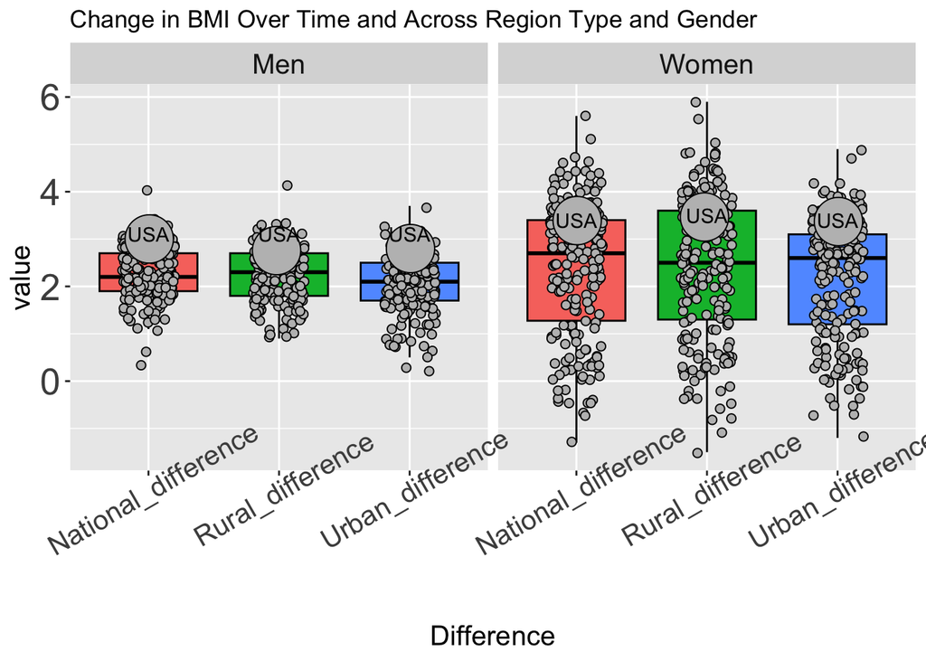

```r
BMI_diff_long[["Country"]] <-BMI_diff_long[["Country"]] %>%
  str_replace( pattern = "United States of America", replacement = "USA")


ggplot(BMI_diff_long, aes(x = Difference, y = value, col = Difference)) +
  geom_boxplot(outlier.shape = NA, color = "black" , aes(fill = Difference)) +
  facet_grid(~ Sex) +
  geom_jitter(data=subset(BMI_diff_long),
              aes(x =Difference, y =value),
              width = .2, size = 2, shape = 21, color = "black", fill = "gray") +
  # This will add the individual country data points
  # The shape 21 allows for a different fill and outline color
  # The width determines how wide the jitter points are plotted
  geom_jitter(data=subset(BMI_diff_long, Country == "USA"),
              aes(x = Difference, y = value),
              width = .02, size = 12, shape = 21, color = "black", fill = "gray") +
  # This will add points that are larger for the USA data
  geom_text(data=subset(BMI_diff_long,  Country == "USA"),
            aes(x =Difference, y = value, label = Country), color = "black") +
  # This will add USA labels to the USA points
  theme(legend.position = "none",
  # This is useful for removing the legend
        axis.text.x = element_text(size = 15,angle = 30),
        # this changes the size and angle of the x axis point labels
        axis.text.y = element_text(size = 20),
        axis.title.y = element_text(size = 15),
        axis.title.x = element_text(size = 15),
        strip.text.x = element_text(size = 15)) +
        # this changes the size of x axis labels for the facet
        ggtitle( "Change in BMI Over Time and Across Region Type and Gender")
```

We can now see that the rate of change from 1985 to 2017 appears to be larger in the women compared to the men in all regions. The group with the largest increase in the USA is the women living in rural areas.

Let’s check the difference with some statistical tests. Remember that these rural differences are measured on the same countries as the urban differences, so we will need to use paired tests to make these comparisons. We can either consider the paired $t$-test or the Wilcoxon signed-rank test. To decide between them, we’ll look at the normality of the paired differences in change over time.